# Day3_sec_ds_lv3_prob2_prob-Copy2

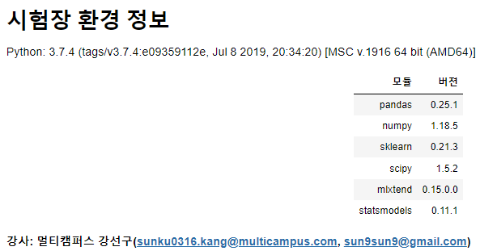

```python
from IPython.display import Image

Image('3-1.png')
```

```python
# 실행 환경 확인

import pandas as pd
import numpy as np
import sklearn
import scipy
import statsmodels
import mlxtend
import sys
import xgboost as xgb

import warnings
warnings.filterwarnings(action = 'ignore')

print(sys.version)
for i in [pd, np, sklearn, scipy, mlxtend, statsmodels, xgb]:
    print(i.__name__, i.__version__)
```

```
3.7.4 (tags/v3.7.4:e09359112e, Jul  8 2019, 20:34:20) [MSC v.1916 64 bit (AMD64)]
pandas 0.25.1
numpy 1.18.5
sklearn 0.21.3
scipy 1.5.2
mlxtend 0.15.0.0
statsmodels 0.11.1
xgboost 0.80
```

```python
# 시각화 모듈 설정
# 참고용 차트를 출력하기 위함
import matplotlib.pyplot as plt
import seaborn as sns

import matplotlib as mpl
import matplotlib.font_manager as fm
plt.rc('font', family='Malgun Gothic')
mpl.rcParams['axes.unicode_minus'] = False
```

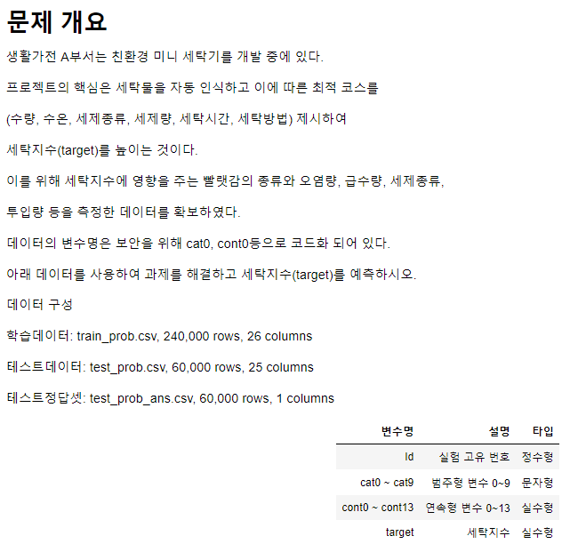

```python
Image('3-2.png')
```

# 전처리(Preprocessing)

train_prob.csv 데이터셋을 대상으로 다음 전처리를 진행하라.

```python
df_train = pd.read_csv('train_prob.csv', index_col='id')
display(df_train.info())
df_train.head()
```

```
<class 'pandas.core.frame.DataFrame'>
Int64Index: 240000 entries, 267387 to 415856
Data columns (total 25 columns):
cat0      240000 non-null object
cat1      240000 non-null object
cat2      240000 non-null object
cat3      240000 non-null object
cat4      240000 non-null object
cat5      240000 non-null object
cat6      240000 non-null object
cat7      240000 non-null object
cat8      240000 non-null object
cat9      240000 non-null object
cont0     240000 non-null float64
cont1     240000 non-null float64
cont2     240000 non-null float64
cont3     240000 non-null float64
cont4     240000 non-null float64
cont5     240000 non-null float64
cont6     240000 non-null float64
cont7     240000 non-null float64
cont8     240000 non-null float64
cont9     240000 non-null float64
cont10    240000 non-null float64
cont11    240000 non-null float64
cont12    240000 non-null float64
cont13    240000 non-null float64
target    240000 non-null float64
dtypes: float64(15), object(10)
memory usage: 47.6+ MB
```

```
None
```

| id | cat0 | cat1 | cat2 | cat3 | cat4 | cat5 | cat6 | cat7 | cat8 | cat9 | ... | cont5 | cont6 | cont7 | cont8 | cont9 | cont10 | cont11 | cont12 | cont13 | target |
| --- | --- | --- | --- | --- | --- | --- | --- | --- | --- | --- | --- | --- | --- | --- | --- | --- | --- | --- | --- | --- | --- |
| 267387 | A | B | B | C | B | B | A | E | G | G | ... | 0.22443 | 0.69220 | 0.30912 | 0.47134 | 0.53290 | 0.97139 | 0.59414 | 0.36856 | 0.42951 | 8.13741 |
| 410037 | A | A | A | A | B | B | A | E | C | F | ... | 0.43278 | 0.97199 | 0.62596 | 0.40193 | 0.49181 | 0.56479 | 0.39386 | 0.36247 | 0.71541 | 7.40427 |
| 139373 | A | A | B | A | B | B | A | E | C | J | ... | 0.36238 | 0.41310 | 0.27010 | 0.40112 | 0.53052 | 0.35635 | 0.33341 | 0.33354 | 0.82542 | 7.98022 |
| 113765 | A | A | A | C | B | B | A | E | C | G | ... | 0.32670 | 0.42301 | 0.28331 | 0.46425 | 0.38302 | 0.38054 | 0.68827 | 0.34895 | 0.73375 | 7.26085 |
| 179915 | A | B | A | C | B | B | A | E | E | L | ... | 0.20121 | 0.37466 | 0.46316 | 0.75578 | 0.55676 | 0.31308 | 0.43157 | 0.32302 | 0.18028 | 7.26448 |

5 rows × 25 columns

## 단계 1

target은 2개의 정규 분포가 합쳐진 모양을 하고 있다.

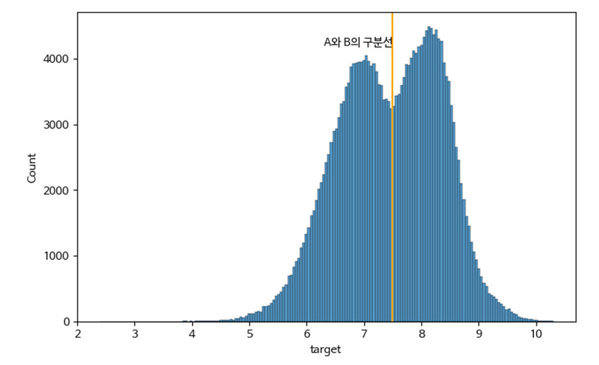

두 분포의 구분점 7.45를 기준으로 target값이 작거나 같으면 A, 초과하면 B로 나눈다.

A 범주이면 True, B이면 False인 파생 변수 target A를 만든다.

```python
df_train['target']
```

```
id
267387    8.13741
410037    7.40427
139373    7.98022
113765    7.26085
179915    7.26448
           ...
320975    7.60537
29591     8.10343
46717     6.93285
463191    6.64854
415856    7.43852
Name: target, Length: 240000, dtype: float64
```

```python
df_train['targetA'] = df_train['target'] <= 7.45
df_train['targetA']
```

```
id
267387    False
410037     True
139373    False
113765     True
179915     True
          ...
320975    False
29591     False
46717      True
463191     True
415856     True
Name: targetA, Length: 240000, dtype: bool
```

```python
x_col = ['cat{}'.format(i) for i in range(3,10)]
df_train[x_col]
```

| id | cat3 | cat4 | cat5 | cat6 | cat7 | cat8 | cat9 |
| --- | --- | --- | --- | --- | --- | --- | --- |
| 267387 | C | B | B | A | E | G | G |
| 410037 | A | B | B | A | E | C | F |
| 139373 | A | B | B | A | E | C | J |
| 113765 | C | B | B | A | E | C | G |
| 179915 | C | B | B | A | E | E | L |
| ... | ... | ... | ... | ... | ... | ... | ... |
| 320975 | C | B | B | A | E | C | I |
| 29591 | C | B | B | A | E | C | F |
| 46717 | C | B | D | A | E | G | F |
| 463191 | C | B | D | A | E | E | F |
| 415856 | C | B | D | A | E | G | I |

240000 rows × 7 columns

```python
for i in range(3, 10) :
    col = 'cat{}'.format(i)
    print(df_train[col].value_counts(normalize = True))
```

```
C    0.611917
A    0.348475
D    0.037521
B    0.002087
Name: cat3, dtype: float64
B    0.991179
A    0.004292
C    0.002512
D    0.002017
Name: cat4, dtype: float64
B    0.496879
D    0.451021
C    0.039179
A    0.012921
Name: cat5, dtype: float64
A    0.975263
B    0.021346
C    0.002708
D    0.000492
I    0.000092
E    0.000058
H    0.000033
G    0.000008
Name: cat6, dtype: float64
E    0.891779
D    0.081492
B    0.019117
G    0.006596
F    0.000942
A    0.000042
C    0.000021
I    0.000013
Name: cat7, dtype: float64
C    0.403096
E    0.315167
G    0.141121
A    0.126408
D    0.012304
F    0.001854
B    0.000050
Name: cat8, dtype: float64
F    0.358100
I    0.166958
L    0.140558
H    0.082596
K    0.069763
A    0.044492
G    0.034667
M    0.032579
J    0.022921
O    0.020700
N    0.013879
B    0.011513
C    0.000683
D    0.000346
E    0.000246
Name: cat9, dtype: float64
```

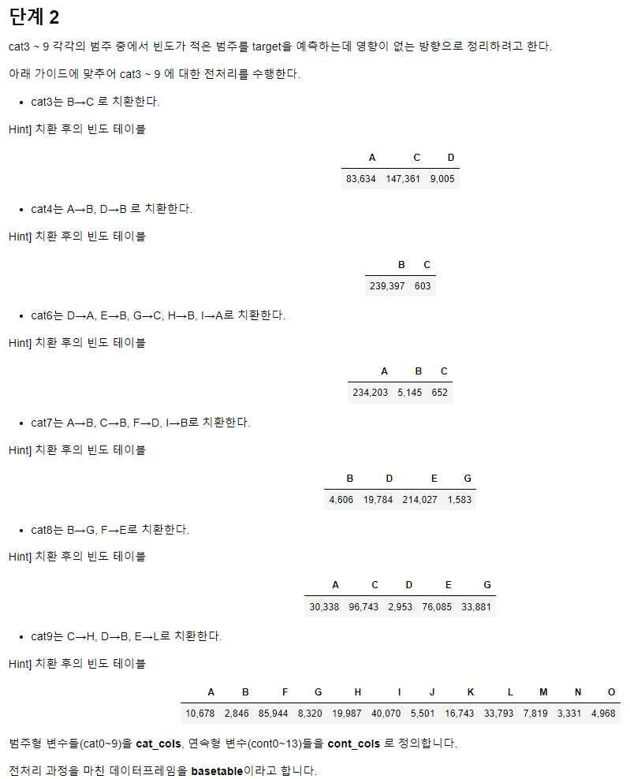

```python
Image('3-3.png')
```

```python
'''
`pandas.replace()` 함수는 DataFrame 또는 Series에서 특정 값을 다른 값으로 바꾸는 데 사용됩니다.
이 함수는 다양한 형태의 값 교체 작업을 지원하며, 단일 값, 리스트, 사전, 정규 표현식 등 여러 가지를 사용할 수 있습니다.

### 함수 시그니처
DataFrame.replace(to_replace=None, value=None, *, inplace=False, limit=None, regex=False, method='pad')

### 주요 인자
- to_replace: 바꿀 값 또는 값들의 집합입니다.
  - 단일 값: 특정 값 하나를 지정하여 변경합니다.
  - 리스트: 여러 값을 리스트로 지정하여 일괄 변경합니다.
  - 사전: {old_value: new_value} 형태의 사전을 사용하여 여러 값을 한번에 변경할 수 있습니다.
- value: 새롭게 대체할 값입니다. `to_replace`가 단일 값, 리스트, 사전일 때 각각에 대해 대응되는 새로운 값을 지정합니다.
  - 단일 값: `to_replace`에서 지정한 값을 모두 이 값으로 바꿉니다.
  - 리스트: `to_replace`가 리스트일 때, 각 값에 대응하는 새로운 값을 리스트로 지정합니다.
  - 사전: `to_replace`가 사전일 때, 각 key에 대응하는 값을 지정합니다.
- inplace: 불리언 값으로, True로 설정하면 원본 DataFrame 또는 Series를 직접 변경하고,
    False이면 변경된 새로운 객체를 반환합니다. 기본값은 False입니다.
- limit: 변경할 최대 횟수를 지정합니다. None이면 제한 없이 모든 값을 변경합니다.
- regex: 불리언 값 또는 사전으로, 정규 표현식을 사용할지를 지정합니다.
    True로 설정하면 `to_replace` 값을 정규 표현식으로 간주합니다.
- method: 결측치 채우기 방식으로, {'pad', 'ffill', 'bfill', 'nearest'} 중 하나를 선택할 수 있습니다.
    결측치를 앞이나 뒤 또는 가까운 값으로 채웁니다.

### 반환값
- 변경된 값을 반영한 새로운 DataFrame 또는 Series를 반환합니다.
    `inplace=True`로 설정한 경우에는 None을 반환합니다.

### 사용 예시
1. 단일 값 변경
   df = pd.DataFrame({'A': [1, 2, 3, 4], 'B': [5, 6, 7, 8]})
   df.replace(1, 100)

2. 여러 값 변경
   df.replace([1, 2], [100, 200])

3. 사전을 사용한 변경
   df.replace({1: 100, 2: 200})

4. 정규 표현식 사용
   df = pd.DataFrame({'A': ['foo', 'fuz', 'bar'], 'B': ['baz', 'qux', 'quux']})
   df.replace(to_replace=r'^f.*', value='prefix', regex=True)

5. inplace 사용
   df.replace(1, 100, inplace=True)

6. 제한된 횟수 변경
   df.replace(1, 100, limit=1)

이 함수는 데이터 클리닝 작업에서 매우 유용하게 사용할 수 있으며, 다양한 데이터 변환 작업에 유연하게 적용할 수 있습니다.
'''
print('')
```

```python
df = pd.DataFrame({'A': [1, 2, 3, 4], 'B': [5, 6, 7, 8]})
print(df.replace(1, 100))
print('-----------------')

print(df.replace([1, 2], [100, 200]))
print('-----------------')

print(df.replace({2: 100, 3: 200}))
print('-----------------')

df = pd.DataFrame({'A': ['foo', 'fuz', 'bar'], 'B': ['baz', 'qux', 'quux']})
print(df.replace(to_replace=r'^f.*', value='prefix', regex=True))
```

```
     A  B
0  100  5
1    2  6
2    3  7
3    4  8
-----------------
     A  B
0  100  5
1  200  6
2    3  7
3    4  8
-----------------
     A  B
0    1  5
1  100  6
2  200  7
3    4  8
-----------------
        A     B
0  prefix   baz
1  prefix   qux
2     bar  quux
```

```python
'''
`pandas.all()` 함수는 Pandas 라이브러리에서 DataFrame 또는 Series의 모든 요소가 True인지 확인하는 데 사용됩니다.
이 함수는 주로 Boolean 데이터나 조건식을 평가할 때 사용됩니다.

### 기본 사용법
#### Series에서의 사용
Series에서 `all()`을 호출하면 모든 요소가 True인지 검사합니다.
# 예제 Series
s = pd.Series([True, True, False])

# 모든 요소가 True인지 검사
result = s.all()
print(result)  # False

#### DataFrame에서의 사용
DataFrame에서 `all()`을 호출하면 기본적으로 각 열(column)에 대해 모든 요소가 True인지 검사합니다.
# 예제 DataFrame
df = pd.DataFrame({
    'A': [True, True, True],
    'B': [True, False, True]
})

# 각 열에 대해 모든 요소가 True인지 검사
result = df.all()
print(result)
출력:
A     True
B    False
dtype: bool

### 매개변수
`pandas.all()` 함수는 다음과 같은 매개변수를 가집니다:
- axis: {0 or 'index', 1 or 'columns'}, 기본값 0
  - 0 또는 'index': 각 열(column)에 대해 평가
  - 1 또는 'columns': 각 행(row)에 대해 평가
- bool_only: bool, 기본값 None
  - Boolean 열만 고려할지 여부를 지정합니다. 기본값은 None으로, 이는 모든 데이터 유형을 고려한다는 의미입니다.
- skipna: bool, 기본값 True
  - NA/null 값은 무시하고 계산할지 여부를 지정합니다. True일 경우 NA 값은 무시됩니다.
- level: int 또는 레이블, 기본값 None
  - 지정된 레벨에서만 동작하도록 멀티 인덱스 (hierarchical index)에 사용할 수 있습니다.

### 예제
#### 특정 축(axis)에 대해 평가
# 예제 DataFrame
df = pd.DataFrame({
    'A': [True, True, True],
    'B': [True, False, True]
})
# 각 행(row)에 대해 모든 요소가 True인지 검사
result = df.all(axis=1)
print(result)
출력:
0     True
1    False
2     True
dtype: bool

#### NA 값 무시
# 예제 Series
s = pd.Series([True, np.nan, True])
# NA 값을 무시하고 검사
result = s.all(skipna=True)
print(result)  # True
# NA 값을 고려하여 검사
result = s.all(skipna=False)
print(result)  # nan

이러한 방식으로 `pandas.all()` 함수는 Series나 DataFrame의 모든 요소가 True인지 간단하게 확인할 수 있는 유용한 도구입니다.
'''
print('')
```

```python
'''
코드는 `repl_list`를 순회하면서, 각 카테고리 열(`catX`)에 대해 특정 값들을
다른 값으로 치환하고, 치환된 결과가 예상된 횟수와 일치하는지 확인하는 작업을 수행합니다.

### 1. 데이터 설명
- `repl_list`: 튜플로 구성된 리스트. 각 튜플은 세 개의 요소로 이루어져 있습니다.
  - 첫 번째 요소(`c`): 카테고리 열 이름 (`catX` 형식의 문자열).
  - 두 번째 요소(`d`): 치환할 값들의 딕셔너리.
      예를 들어, `{'B': 'C'}`는 'B'를 'C'로 치환한다는 의미입니다.
  - 세 번째 요소(`cnt`): 치환 후 각 값들의 예상 빈도수를 나타내는 리스트.

### 2. 코드 동작 단계
- `repl_list`를 순회하면서 각 튜플의 요소들을 변수
    `c`, `d`, `cnt`에 할당하고 출력합니다.
- `df_train` 데이터프레임의 `c` 열에 대해 `d` 딕셔너리에 정의된 값들을 치환합니다.
    예를 들어, `d`가 `{'B': 'C'}`인 경우 `df_train[c]`의 'B' 값을 'C'로 치환합니다.
- 치환된 열 `s_repl`의 고유값 개수가 `cnt`의 길이와 일치하는지 확인합니다.
    일치하지 않으면 오류를 출력합니다.
- `s_repl.value_counts().sort_index() == cnt`은 치환된 열의 값별 빈도수가 `cnt` 리스트와 일치하는지 확인하는 조건입니다.
    `sort_index()`를 사용하여 값들을 정렬한 후 비교합니다.
- 위 조건이 만족되지 않으면 오류 메시지와 함께 `s_repl`의 값별 빈도수를 출력합니다.
- 오류가 발생하면 반복을 중단합니다.
- 치환된 열 `s_repl`를 원래 데이터프레임의 열 `df_train[c]`에 다시 할당합니다.

### 전체 흐름 정리
1. `repl_list`의 각 요소를 순회하면서 각 카테고리 열(`catX`)에 대해 치환 작업을 수행합니다.
2. 치환된 값의 빈도수가 예상 빈도수와 일치하는지 확인합니다.
3. 일치하지 않으면 오류 메시지를 출력하고 반복을 중단합니다.
4. 일치하면 치환된 값을 데이터프레임에 다시 저장합니다.

코드는 데이터프레임의 특정 열에 대해 지정된 값 치환 작업을 수행하고, 그 결과가 예상된 빈도수와 일치하는지 검증하는 기능을 합니다.
'''

#cat3는 B→C 로 치환한다.
# A, C,D
# 83634, 147361, 9005

repl_list = [
    ('cat3', {'B': 'C'}, [83634, 147361, 9005]),
    ('cat4', {'A': 'B', 'D': 'B'}, [239397, 603]),
    ('cat6', {'D': 'A', 'E': 'B', 'G': 'C', 'H': 'B', 'I': 'A'}, [234203, 5145, 652]),
    ('cat7', {'A': 'B', 'C': 'B', 'F': 'D', 'I': 'B'}, [4606, 19784, 214027, 1583]),
    ('cat8', {'B': 'G', 'F': 'E'}, [30338, 96743, 2953, 76085, 33881]),
    ('cat9', {'C': 'H', 'D': 'B', 'E': 'L'}, [10678, 2846, 85944, 8320, 19987, 40070, 5501, 16743, 33793, 7819, 3331, 4968])
]

print(type(repl_list[0]))

for c, d, cnt in repl_list:
    print(c, d, cnt)
    s_repl = df_train[c].replace(d)
    if s_repl.nunique() != len(cnt) or not (s_repl.value_counts().sort_index() == cnt).all():
        print("error", s_repl.value_counts())
        break
    df_train[c] = s_repl
```

```
<class 'tuple'>
cat3 {'B': 'C'} [83634, 147361, 9005]
cat4 {'A': 'B', 'D': 'B'} [239397, 603]
cat6 {'D': 'A', 'E': 'B', 'G': 'C', 'H': 'B', 'I': 'A'} [234203, 5145, 652]
cat7 {'A': 'B', 'C': 'B', 'F': 'D', 'I': 'B'} [4606, 19784, 214027, 1583]
cat8 {'B': 'G', 'F': 'E'} [30338, 96743, 2953, 76085, 33881]
cat9 {'C': 'H', 'D': 'B', 'E': 'L'} [10678, 2846, 85944, 8320, 19987, 40070, 5501, 16743, 33793, 7819, 3331, 4968]
```

```python
cat_cols = ['cat{}'.format(i) for i in range(10)]
print('cat_cols = ', cat_cols)

cont_cols = ['cont{}'.format(i) for i in range(14)]
print('cont_cols = ', cont_cols)

df_basetable = df_train.copy()
df_basetable
```

```
cat_cols =  ['cat0', 'cat1', 'cat2', 'cat3', 'cat4', 'cat5', 'cat6', 'cat7', 'cat8', 'cat9']
cont_cols =  ['cont0', 'cont1', 'cont2', 'cont3', 'cont4', 'cont5', 'cont6', 'cont7', 'cont8', 'cont9', 'cont10', 'cont11', 'cont12', 'cont13']
```

| id | cat0 | cat1 | cat2 | cat3 | cat4 | cat5 | cat6 | cat7 | cat8 | cat9 | ... | cont6 | cont7 | cont8 | cont9 | cont10 | cont11 | cont12 | cont13 | target | targetA |
| --- | --- | --- | --- | --- | --- | --- | --- | --- | --- | --- | --- | --- | --- | --- | --- | --- | --- | --- | --- | --- | --- |
| 267387 | A | B | B | C | B | B | A | E | G | G | ... | 0.69220 | 0.30912 | 0.47134 | 0.53290 | 0.97139 | 0.59414 | 0.36856 | 0.42951 | 8.13741 | False |
| 410037 | A | A | A | A | B | B | A | E | C | F | ... | 0.97199 | 0.62596 | 0.40193 | 0.49181 | 0.56479 | 0.39386 | 0.36247 | 0.71541 | 7.40427 | True |
| 139373 | A | A | B | A | B | B | A | E | C | J | ... | 0.41310 | 0.27010 | 0.40112 | 0.53052 | 0.35635 | 0.33341 | 0.33354 | 0.82542 | 7.98022 | False |
| 113765 | A | A | A | C | B | B | A | E | C | G | ... | 0.42301 | 0.28331 | 0.46425 | 0.38302 | 0.38054 | 0.68827 | 0.34895 | 0.73375 | 7.26085 | True |
| 179915 | A | B | A | C | B | B | A | E | E | L | ... | 0.37466 | 0.46316 | 0.75578 | 0.55676 | 0.31308 | 0.43157 | 0.32302 | 0.18028 | 7.26448 | True |
| ... | ... | ... | ... | ... | ... | ... | ... | ... | ... | ... | ... | ... | ... | ... | ... | ... | ... | ... | ... | ... | ... |
| 320975 | A | A | A | C | B | B | A | E | C | I | ... | 0.40968 | 0.62906 | 0.31427 | 0.43718 | 0.40494 | 0.69718 | 0.34519 | 0.67524 | 7.60537 | False |
| 29591 | A | B | A | C | B | B | A | E | C | F | ... | 0.74914 | 0.82530 | 0.46395 | 0.83396 | 0.71724 | 0.69450 | 0.33008 | 0.28460 | 8.10343 | False |
| 46717 | A | B | B | C | B | D | A | E | G | F | ... | 0.47447 | 0.79777 | 0.87541 | 0.63918 | 0.58994 | 0.77751 | 0.86388 | 0.74568 | 6.93285 | True |
| 463191 | A | A | A | C | B | D | A | E | E | F | ... | 0.21360 | 0.22158 | 0.06595 | 0.61991 | 0.62167 | 0.25545 | 0.33329 | 0.28366 | 6.64854 | True |
| 415856 | A | A | A | C | B | D | A | E | G | I | ... | 0.83486 | 0.48463 | 0.90318 | 0.81729 | 0.57672 | 0.46053 | 0.91726 | 0.25874 | 7.43852 | True |

240000 rows × 26 columns

던(Dunn) 지수는 군집화(clustering) 품질을 평가하는 데 사용되는 지표 중 하나입니다.

이 지수는 군집 간 분리도를 최대화하고 군집 내 응집도를 최소화하려고 합니다.

Dunn 지수는 다음과 같은 개념을 기반으로 합니다:

1. **군집 간 분리도 (Inter-cluster distance)**: 서로 다른 군집 간의 거리입니다. 이는 군집 간의 최소 거리(minimum distance)를 의미합니다.
2. **군집 내 응집도 (Intra-cluster distance)**: 같은 군집 내 데이터 포인트들 간의 거리입니다. 이는 군집 내의 최대 거리(maximum distance)를 의미합니다.

### Dunn 지수 정의

던 지수는 다음과 같이 정의됩니다:

$D = \frac{\min_{1 \leq i < j \leq k} \delta(C_i, C_j)}{\max_{1 \leq l \leq k} \Delta(C_l)} $

여기서, 여기서,

- $( \delta(C_i, C_j) $): 군집 $( C_i $)와 군집 $( C_j $) 간의 거리 (보통 최소 거리로 정의됨)
- $( \Delta(C_l) $): 군집 $( C_l $) 내의 거리 (보통 최대 거리로 정의됨)
- $( k $): 군집의 수

### 계산 방법

1. 군집 간 최소 거리 ( $\delta(C_i, C_j) $): 각 군집 쌍에 대해 모든 데이터 포인트 간의 거리를 계산하고, 그 중 최소 거리를 선택합니다.
2. 군집 내 최대 거리 ( $\Delta(C_l) $): 각 군집에 대해 모든 데이터 포인트 간의 거리를 계산하고, 그 중 최대 거리를 선택합니다.
3. Dunn 지수 계산: 위의 공식을 사용하여 Dunn 지수를 계산합니다.

### 특성

- Dunn 지수가 클수록 군집화의 품질이 높다고 간주됩니다.
- 높은 Dunn 지수는 군집 간의 분리도가 크고, 군집 내 응집도가 낮음을 의미합니다.

### 예제

다음은 Python을 사용하여 Dunn 지수를 계산하는 간단한 예제입니다:

```
import numpy as np
from sklearn.metrics import pairwise_distances

def dunn_index(X, labels):
    # 데이터 포인트 간의 거리 행렬 계산
    distances = pairwise_distances(X)

    # 군집 식별
    clusters = np.unique(labels)

    # 군집 내 최대 거리 계산
    intra_dists = []
    for cluster in clusters:
        cluster_points = X[labels == cluster]
        if len(cluster_points) > 1:
            intra_dist = np.max(pairwise_distances(cluster_points))
        else:
            intra_dist = 0
        intra_dists.append(intra_dist)
    max_intra_dist = np.max(intra_dists)

    # 군집 간 최소 거리 계산
    inter_dists = []
    for i in range(len(clusters)):
        for j in range(i + 1, len(clusters)):
            cluster_i_points = X[labels == clusters[i]]
            cluster_j_points = X[labels == clusters[j]]
            inter_dist = np.min(pairwise_distances(cluster_i_points, cluster_j_points))
            inter_dists.append(inter_dist)
    min_inter_dist = np.min(inter_dists)

    # Dunn 지수 계산
    dunn_index = min_inter_dist / max_intra_dist
    return dunn_index

# 예제 데이터
from sklearn.datasets import make_blobs

X, labels = make_blobs(n_samples=150, centers=3, random_state=42)

# Dunn 지수 계산
dunn = dunn_index(X, labels)
print(f'Dunn Index: {dunn}')
```

이 예제에서는 `pairwise_distances` 함수를 사용하여 데이터 포인트 간의 거리를 계산하고, Dunn 지수를 계산합니다.

이 방법을 통해 군집화의 품질을 평가할 수 있습니다.

**TIP!**: Dunn Index 구하기

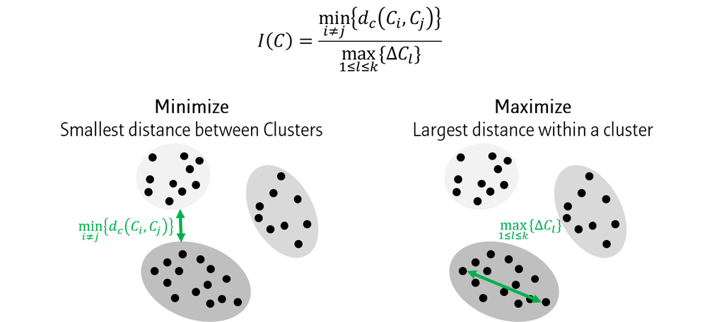

```python
# 예시를 들기에는 데이터셋이 커서 1%만 뽑겠습니다.
df_dunn = df_train.sample(frac=0.01, random_state=123)
len(df_dunn)
```

```
2400
```

**Question**

cat5는 cont0~13 연속형 변수에 대한 군집화의 결과 생긴

데이터 포인트의 소속 군집이라고 가정합니다.

**df_dunn**에서 cat5 군집에 대한 Dunn-Index로 측정하세요.

**Python 함수가이드**

```
from scipy.spatial.distance import pdist, cdist, squareform
```

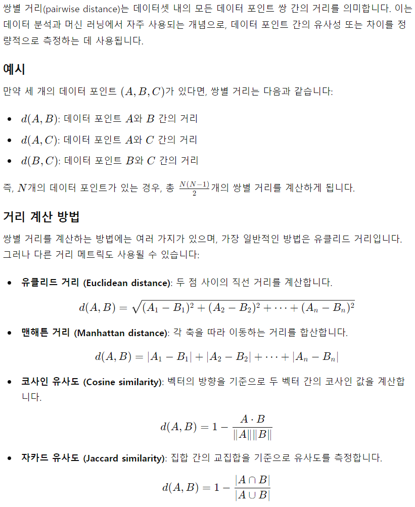

```python
Image('4.png')
```

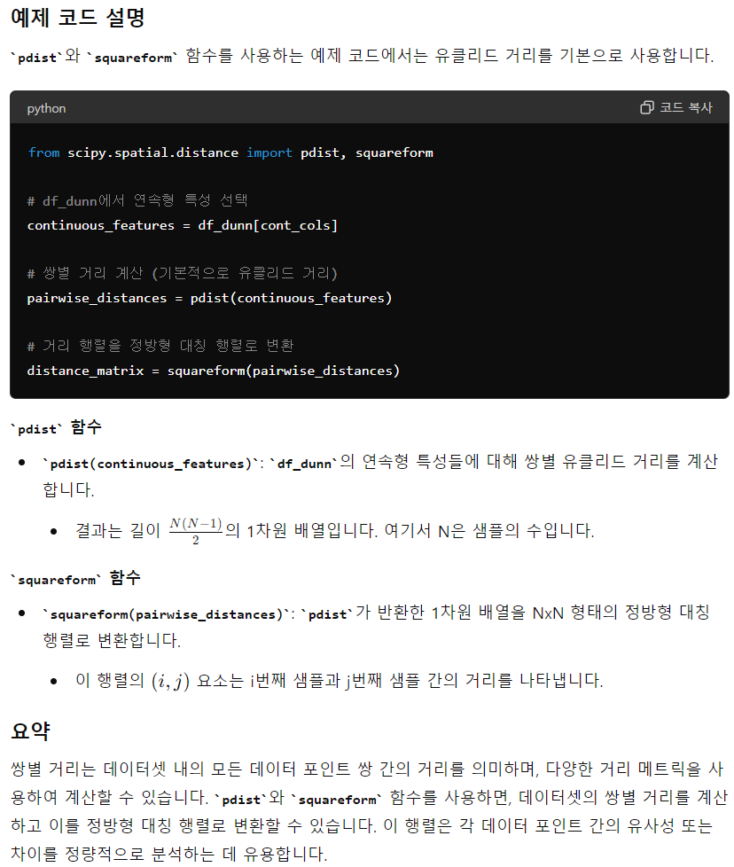

```python
Image('5.png')
```

```python
'''
`pdist()` 함수는 SciPy 라이브러리의 `scipy.spatial.distance` 모듈에 속해 있으며,
여러 관측값 사이의 쌍별 거리를 계산하는 데 사용됩니다.
`pdist()`는 입력으로 주어진 n x m 크기의 배열에서 n개의 관측값에 대해
모든 쌍의 거리를 계산하고, 결과를 압축된 형식으로 반환합니다. 이 함수는 다양한 거리 메트릭을 지원합니다.

## pdist() 함수의 인자
1. X (array_like):
   - n x m 크기의 입력 배열입니다. 여기서 n은 관측값의 수이고, m은 각 관측값의 차원입니다.

2. metric (str or function, optional):
   - 거리를 계산할 메트릭을 지정합니다. 기본값은 'euclidean' (유클리드 거리)입니다.
   - 문자열로 메트릭을 지정할 수 있으며, 지원되는 메트릭에는 'euclidean', 'cityblock' (맨해튼 거리),
       'cosine', 'hamming' 등 여러 가지가 있습니다.
   - 사용자 정의 함수도 사용할 수 있습니다. 이 경우 함수는 두 개의 1차원 배열을 입력으로 받아 거리를 계산하고
       하나의 스칼라 값을 반환해야 합니다.

3. Other Parameters:
   - `p`: Minkowski 거리 메트릭을 사용하는 경우, 이 인자는 p-노름의 차수를 나타냅니다.
       예를 들어, `metric='minkowski'`와 `p=3`를 지정하면 3-노름을 사용하여 거리를 계산합니다.

## pdist() 함수의 반환값
- Y (ndarray):
  - n x n 거리 행렬의 상삼각 부분을 1차원 배열로 평탄화한 배열입니다. 길이는 n(n-1)/2입니다.
  - 이 배열은 `scipy.spatial.distance.squareform()` 함수를 사용하여 거리 행렬로 변환할 수 있습니다.
'''

# 아래 코드는 세 개의 2차원 데이터 포인트 간의 유클리드 거리를 계산하고, 그 결과를 거리 행렬 형태로 출력합니다.

import numpy as np
from scipy.spatial.distance import pdist, squareform

# 예제 데이터
data = np.array([[0, 1], [1, 0], [2, 2]])

# 유클리드 거리 계산
distances = pdist(data, metric='euclidean')
print('distances = ', distances)

distance_matrix = squareform(distances)
print('distance_matrix')
print('----------------------------------------------')
distance_matrix
```

```
distances =  [1.41421356 2.23606798 2.23606798]
distance_matrix
----------------------------------------------
```

```
array([[0.        , 1.41421356, 2.23606798],
       [1.41421356, 0.        , 2.23606798],
       [2.23606798, 2.23606798, 0.        ]])
```

```python
# 샘플 데이터 (4개의 2차원 포인트)
X = np.array([[0, 1], [1, 0], [2, 0], [3, 4]])

# 유클리드 거리 계산
Y = pdist(X, metric='euclidean')

# 거리 벡터 출력
print("거리 벡터:", Y)

# 거리 행렬로 변환
distance_matrix = squareform(Y)
print("거리 행렬:\n", distance_matrix)
```

```
거리 벡터: [1.41421356 2.23606798 4.24264069 1.         4.47213595 4.12310563]
거리 행렬:
 [[0.         1.41421356 2.23606798 4.24264069]
 [1.41421356 0.         1.         4.47213595]
 [2.23606798 1.         0.         4.12310563]
 [4.24264069 4.47213595 4.12310563 0.        ]]
```

```python
import numpy as np
from scipy.spatial.distance import pdist

# 샘플 데이터 (4개의 2차원 포인트)
X = np.array([[0, 1], [1, 0], [2, 0], [3, 4]])

# 사용자 정의 거리 함수 (예: 두 벡터의 원소 차이의 절대값 합)
def custom_metric(u, v):
    return np.sum(np.abs(u - v))

# 사용자 정의 거리 함수로 거리 계산
Y = pdist(X, metric=custom_metric)

# 거리 벡터 출력
print("사용자 정의 거리 벡터:", Y)
```

```
사용자 정의 거리 벡터: [2. 3. 6. 1. 6. 5.]
```

```python
'''
코드는 `df_dunn` 데이터프레임의 연속형 특성(`cont_cols`)에 대한 쌍별 거리 행렬을 계산하고, 이를 정방행렬 형태로 변환합니다.

* 쌍별 거리(pairwise distance)는 데이터 분석 및 기계 학습에서 각 데이터 포인트 간의 거리를 계산하는 방법을 의미합니다.
이를 통해 데이터의 구조와 유사성을 파악할 수 있습니다.
쌍별 거리 계산은 특히 군집화(clustering), 최근접 이웃 탐색(knn), 다차원 척도법(MDS) 등 여러 알고리즘에서 중요하게 사용됩니다.

# 1. 데이터 샘플링
`df_train` 데이터프레임에서 1% 샘플링하여 `df_dunn` 데이터프레임을 생성합니다.
- `frac=0.01`: `df_train` 데이터프레임의 1%를 무작위로 샘플링합니다.
- `random_state=123`: 무작위 샘플링의 재현성을 보장하기 위해 시드를 설정합니다.

# 2. 쌍별 거리 계산
`df_dunn`의 연속형 특성에 대해 쌍별 거리를 계산합니다.
## 내부 동작 설명
- `df_dunn[cont_cols]`: `df_dunn` 데이터프레임에서 연속형 특성만 선택합니다.
    `cont_cols`는 연속형 특성의 컬럼 이름 리스트입니다.
- `pdist(df_dunn[cont_cols])`: 선택된 연속형 특성에 대해 각 데이터 포인트 간의 쌍별 거리를 계산합니다.
    `pdist`는 압축된 거리 행렬을 반환합니다. 기본적으로 유클리드 거리를 계산하지만, 다른 거리 메트릭을 사용할 수도 있습니다.
  - 예를 들어, `pdist(df_dunn[cont_cols], metric='euclidean')`는 유클리드 거리를 계산합니다.
## 거리 행렬 변환
- `squareform(pdist(...))`: `pdist`가 반환한 압축된 거리 행렬을 정방형 거리 행렬로 변환합니다.
  - `squareform` 함수는 압축된 거리 벡터를 정방형 대칭 행렬로 변환합니다. 결과는 NxN 형태의 행렬로, 여기서 N은 샘플 수입니다.

# 전체 과정 요약
1. `df_train` 데이터프레임에서 1% 샘플링하여 `df_dunn` 데이터프레임을 생성합니다.
2. `df_dunn`의 연속형 특성에 대해 쌍별 거리를 계산합니다.
3. 쌍별 거리 행렬을 정방형 대칭 행렬로 변환합니다.

결과적으로, `squareform(pdist(df_dunn[cont_cols]))`은 `df_dunn` 데이터프레임의
연속형 특성 간의 쌍별 거리 정보를 포함하는 NxN 형태의 거리 행렬을 반환합니다.
이 행렬의 (i, j) 요소는 i번째 샘플과 j번째 샘플 간의 거리를 나타냅니다.
'''

from scipy.spatial.distance import pdist, cdist, squareform

# pdist는 주어진 행렬의 거리 행렬을 구합니다.
# 대칭 행렬인 거리 행렬을 효율적으로 담기 위해
# 삼각 영역의 값을 1차원 배열로 저장합니다.
# 효율화된 1차원 배열의 거리 행렬 -> 행렬 형태로,
# 행렬 형태는 ->  효율화된 1차원 배열의 거리 행렬  로 바꾸어줍니다.

squareform(pdist(df_dunn[cont_cols]))
```

```
array([[0.        , 1.66286356, 1.67872855, ..., 1.61131483, 1.74132879,
        0.75583433],
       [1.66286356, 0.        , 1.22627566, ..., 1.33120631, 0.85189025,
        1.71017092],
       [1.67872855, 1.22627566, 0.        , ..., 0.9789981 , 1.17031726,
        1.48386611],
       ...,
       [1.61131483, 1.33120631, 0.9789981 , ..., 0.        , 1.13333429,
        1.42148633],
       [1.74132879, 0.85189025, 1.17031726, ..., 1.13333429, 0.        ,
        1.79540053],
       [0.75583433, 1.71017092, 1.48386611, ..., 1.42148633, 1.79540053,
        0.        ]])
```

```python
df_dunn.groupby('cat5')['cont0'].apply(lambda x: print(x))
```

```
id
366778    0.68308
255453    0.36268
300436    0.52435
153248    0.76304
37546     0.22057
278208    0.47434
290192    0.49814
317072    0.50376
279773    0.47409
67084     0.61741
408658    0.34193
159028    0.13903
72799     0.46590
172901    0.68643
```

[output cut: 62 more lines]

```
cat5
A    None
B    None
C    None
D    None
Name: cont0, dtype: object
```

```python
aa = df_dunn.groupby('cat5')[cont_cols].apply(lambda x: np.max(pdist(x)))
print(aa)
type(aa)
```

```
cat5
A    1.748697
B    2.093003
C    1.957944
D    2.201251
dtype: float64
```

```
pandas.core.series.Series
```

```python
'''
# `max_diam` 계산
`df_dunn`의 `cat5` 그룹별로 연속형 특성의 최대 쌍별 거리를 계산하고, 그 중 최대 값을 찾습니다.
## 내부 동작 설명
- `df_dunn.groupby('cat5')[cont_cols]`: `cat5`별로 데이터를 그룹화하고, 연속형 특성(`cont_cols`)만 선택합니다.
- `.apply(lambda x: np.max(pdist(x)))`: 각 그룹에 대해 함수(`lambda x: np.max(pdist(x))`)를 적용합니다.
  - `pdist(x)`: 그룹 별로 데이터 포인트 간의 쌍별 거리를 계산합니다.
  - `np.max(pdist(x))`: 계산된 쌍별 거리 중 최대 값을 찾습니다.
- `.max()`: 각 그룹별로 계산된 최대 값들 중에서 최대 값을 찾습니다.
'''

# 각 군집의 직경: groupby ~ apply ~ pdist 군집내의
# 데이터 포인트 중 최대값을 구합니다
# 이들의 최대값을 구합니다.

max_diam = df_dunn.groupby('cat5')[cont_cols].apply(lambda x: np.max(pdist(x))).max()

max_diam
```

```
2.2012507003065327
```

```python
df_dunn['cat5'].value_counts()
```

```
B    1185
D    1086
C      93
A      36
Name: cat5, dtype: int64
```

```python
'''
`cdist()` 함수는 SciPy 라이브러리의 `scipy.spatial.distance` 모듈에 속해 있으며, 두 집합 간의 쌍별 거리를 계산하는 데 사용됩니다.
`pdist()` 함수와 유사하지만, `cdist()`는 두 개의 입력 배열 간의 거리를 계산합니다.

## cdist() 함수의 인자
1. XA (array_like):
   - m x n 크기의 입력 배열입니다. 여기서 m은 첫 번째 집합의 관측값의 수이고, n은 각 관측값의 차원입니다.
2. XB (array_like):
   - p x n 크기의 입력 배열입니다. 여기서 p는 두 번째 집합의 관측값의 수이고, n은 각 관측값의 차원입니다.
   - `XA`와 `XB`는 동일한 차원(n)을 가져야 합니다.
3. metric (str or function, optional):
   - 거리를 계산할 메트릭을 지정합니다. 기본값은 'euclidean' (유클리드 거리)입니다.
   - 문자열로 메트릭을 지정할 수 있으며, 지원되는 메트릭에는 'euclidean', 'cityblock' (맨해튼 거리),
       'cosine', 'hamming' 등 여러 가지가 있습니다.
   - 사용자 정의 함수도 사용할 수 있습니다.
       이 경우 함수는 두 개의 1차원 배열을 입력으로 받아 거리를 계산하고 하나의 스칼라 값을 반환해야 합니다.

## cdist() 함수의 반환값
- Y (ndarray):
  - m x p 크기의 거리 행렬입니다. 이 행렬의 각 요소 \( Y[i, j] \)는 `XA[i]`와 `XB[j]` 사이의 거리를 나타냅니다.
'''
print('')
```

```python
# 위 설명용 예제 1
import numpy as np
from scipy.spatial.distance import cdist

# 샘플 데이터
XA = np.array([[0, 1], [1, 0], [2, 0]])
XB = np.array([[0, 0], [1, 1], [3, 3]])

# 유클리드 거리 계산
Y = cdist(XA, XB, metric='euclidean')

# 거리 행렬 출력
print("유클리드 거리 행렬:\n", Y)
```

```
유클리드 거리 행렬:
 [[1.         1.         3.60555128]
 [1.         1.         3.60555128]
 [2.         1.41421356 3.16227766]]
```

```python
# 위 설명용 예제 2
# 샘플 데이터
XA = np.array([[0, 1], [1, 0], [2, 0]])
XB = np.array([[0, 0], [1, 1], [3, 3]])

# 맨해튼 거리 계산
Y_manhattan = cdist(XA, XB, metric='cityblock')
print("맨해튼 거리 행렬:\n", Y_manhattan)

# 코사인 거리 계산
Y_cosine = cdist(XA, XB, metric='cosine')
print("코사인 거리 행렬:\n", Y_cosine)
```

```
맨해튼 거리 행렬:
 [[1. 1. 5.]
 [1. 1. 5.]
 [2. 2. 4.]]
코사인 거리 행렬:
 [[       nan 0.29289322 0.29289322]
 [       nan 0.29289322 0.29289322]
 [       nan 0.29289322 0.29289322]]
```

```python
# 위 설명용 예제 3
# 샘플 데이터
XA = np.array([[0, 1], [1, 0], [2, 0]])
XB = np.array([[0, 0], [1, 1], [3, 3]])

# 사용자 정의 거리 함수 (예: 두 벡터의 원소 차이의 제곱합)
def custom_metric(u, v):
    return np.sum((u - v) ** 2)

# 사용자 정의 거리 함수로 거리 계산
Y_custom = cdist(XA, XB, metric=custom_metric)
print("사용자 정의 거리 행렬:\n", Y_custom)
```

```
사용자 정의 거리 행렬:
 [[ 1.  1. 13.]
 [ 1.  1. 13.]
 [ 4.  2. 10.]]
```

```python
'''
# 두 그룹 간의 거리 행렬 크기 확인
`cat5`가 'B'인 그룹과 'C'인 그룹 간의 거리 행렬의 크기를 확인합니다.
## 내부 동작 설명
- `df_dunn.loc[df_dunn['cat5'] == 'B', cont_cols]`: `df_dunn` 데이터프레임에서 `cat5`가 'B'인 행과 연속형 특성 열을 선택합니다.
- `df_dunn.loc[df_dunn['cat5'] == 'C', cont_cols]`: `df_dunn` 데이터프레임에서 `cat5`가 'C'인 행과 연속형 특성 열을 선택합니다.
- `cdist(..., ...)`: 두 데이터 세트 간의 거리 행렬을 계산합니다.
    각 행 간의 거리를 계산하여 NxM 형태의 행렬을 반환합니다.
    여기서 N은 첫 번째 데이터 세트의 행 수, M은 두 번째 데이터 세트의 행 수입니다.
- `.shape`: 거리 행렬의 크기를 반환합니다. 이는 (N, M) 형태의 튜플입니다.
'''

# cdist 두 행렬의 데이터 포인트의 간의 거리를 구합니다.

cdist(
    df_dunn.loc[df_dunn['cat5'] == 'B', cont_cols],
    df_dunn.loc[df_dunn['cat5'] == 'C', cont_cols]
).shape
```

```
(1185, 93)
```

```python
df_dunn.groupby('cat5').apply(lambda x: print(x.name))
```

```
A
B
C
D
```

```python
# 아래 aa의 출력결과
'''
cat5	0
A
"[[0.58717836 1.58296339 1.60420365 ... 1.42868625 1.61155058 0.7716703 ]
 [1.70179351 0.94048491 0.97605291 ... 1.25173579 0.91971822 1.79583324]
 [1.31410905 1.38177768 1.04965036 ... 1.04163162 1.48570929 1.0530518 ]
 ...
 [1.78746079 0.79948435 0.77531618 ... 1.22995984 1.00195432 1.64595579]
 [1.58436012 0.8964494  1.00013013 ... 1.22407665 1.08834789 1.42170805]
 [1.55001706 1.00864422 1.11399409 ... 0.88038931 0.88855845 1.47783885]]"
B
"[[1.67872855 1.22627566 1.28801869 ... 1.10295128 0.83450733 1.48386611]
 [1.36997505 1.01318659 1.14413238 ... 1.15929632 1.09640529 1.39730898]
 [1.8053872  1.21073148 1.20246303 ... 1.21914999 0.72640205 1.59652252]
 ...
 [1.53538022 0.87212857 1.03875897 ... 1.16819038 0.96699797 1.55304972]
 [1.61131483 1.33120631 1.42308713 ... 0.96132576 1.26033785 1.42148633]
 [1.74132879 0.85189025 1.28682037 ... 1.04942338 1.00217257 1.79540053]]"
C
"[[1.36027664 1.08285177 0.65536688 ... 1.1605751  1.13119318 1.23325638]
 [1.01663036 1.3364482  1.10305591 ... 1.12091244 1.18877104 1.11195993]
 [1.14441929 1.53117778 1.29229342 ... 1.35139563 1.33862088 1.12575984]
 ...
 [1.61238678 0.96713148 0.79268056 ... 1.30376009 1.07739418 1.48705644]
 [0.82250688 1.27383022 1.33354039 ... 1.34730292 1.22506547 0.92543872]
 [1.33516388 1.07549497 0.80976135 ... 1.11044519 0.97604246 1.33360525]]"
D
"[[1.67872855 1.36997505 1.8053872  ... 1.53538022 1.61131483 1.74132879]
 [1.22627566 1.01318659 1.21073148 ... 0.87212857 1.33120631 0.85189025]
 [1.28801869 1.14413238 1.20246303 ... 1.03875897 1.42308713 1.28682037]
 ...
 [1.10295128 1.15929632 1.21914999 ... 1.16819038 0.96132576 1.04942338]
 [0.83450733 1.09640529 0.72640205 ... 0.96699797 1.26033785 1.00217257]
 [1.48386611 1.39730898 1.59652252 ... 1.55304972 1.42148633 1.79540053]]"
'''

aa = df_dunn.groupby('cat5').apply(
    lambda x: print(cdist(x[cont_cols], df_dunn.loc[df_dunn['cat5'] != x.name, cont_cols])
)
                                  )
#aa.to_frame().to_csv('dunn.csv')
#print(type(aa))
```

```
[[0.58717836 1.58296339 1.60420365 ... 1.42868625 1.61155058 0.7716703 ]
 [1.70179351 0.94048491 0.97605291 ... 1.25173579 0.91971822 1.79583324]
 [1.31410905 1.38177768 1.04965036 ... 1.04163162 1.48570929 1.0530518 ]
 ...
 [1.78746079 0.79948435 0.77531618 ... 1.22995984 1.00195432 1.64595579]
 [1.58436012 0.8964494  1.00013013 ... 1.22407665 1.08834789 1.42170805]
 [1.55001706 1.00864422 1.11399409 ... 0.88038931 0.88855845 1.47783885]]
[[1.67872855 1.22627566 1.28801869 ... 1.10295128 0.83450733 1.48386611]
 [1.36997505 1.01318659 1.14413238 ... 1.15929632 1.09640529 1.39730898]
 [1.8053872  1.21073148 1.20246303 ... 1.21914999 0.72640205 1.59652252]
 ...
 [1.53538022 0.87212857 1.03875897 ... 1.16819038 0.96699797 1.55304972]
 [1.61131483 1.33120631 1.42308713 ... 0.96132576 1.26033785 1.42148633]
 [1.74132879 0.85189025 1.28682037 ... 1.04942338 1.00217257 1.79540053]]
[[1.36027664 1.08285177 0.65536688 ... 1.1605751  1.13119318 1.23325638]
 [1.01663036 1.3364482  1.10305591 ... 1.12091244 1.18877104 1.11195993]
 [1.14441929 1.53117778 1.29229342 ... 1.35139563 1.33862088 1.12575984]
 ...
 [1.61238678 0.96713148 0.79268056 ... 1.30376009 1.07739418 1.48705644]
 [0.82250688 1.27383022 1.33354039 ... 1.34730292 1.22506547 0.92543872]
 [1.33516388 1.07549497 0.80976135 ... 1.11044519 0.97604246 1.33360525]]
[[1.67872855 1.36997505 1.8053872  ... 1.53538022 1.61131483 1.74132879]
 [1.22627566 1.01318659 1.21073148 ... 0.87212857 1.33120631 0.85189025]
 [1.28801869 1.14413238 1.20246303 ... 1.03875897 1.42308713 1.28682037]
 ...
 [1.10295128 1.15929632 1.21914999 ... 1.16819038 0.96132576 1.04942338]
 [0.83450733 1.09640529 0.72640205 ... 0.96699797 1.26033785 1.00217257]
 [1.48386611 1.39730898 1.59652252 ... 1.55304972 1.42148633 1.79540053]]
```

```python
aa = df_dunn.groupby('cat5').apply(
    lambda x: np.min(cdist(x[cont_cols], df_dunn.loc[df_dunn['cat5'] != x.name, cont_cols]))
)
aa
```

```
cat5
A    0.262578
B    0.173348
C    0.255460
D    0.173348
dtype: float64
```

```python
aa = df_dunn.groupby('cat5').apply(
    lambda x : x.name
)

print(type(aa))
aa
```

```
<class 'pandas.core.series.Series'>
```

```
cat5
A    A
B    B
C    C
D    D
dtype: object
```

```python
aa = df_dunn.groupby('cat5').apply(
    lambda x : df_dunn['cat5'] != x.name
)

print(type(aa))
aa.T
```

```
<class 'pandas.core.frame.DataFrame'>
```

| cat5 id | A | B | C | D |
| --- | --- | --- | --- | --- |
| 309145 | True | True | True | False |
| 368647 | True | True | True | False |
| 487072 | True | False | True | True |
| 490811 | True | False | True | True |
| 484687 | True | True | True | False |
| ... | ... | ... | ... | ... |
| 291689 | True | False | True | True |
| 108894 | True | True | True | False |
| 277966 | True | False | True | True |
| 137263 | True | False | True | True |
| 159345 | True | True | True | False |

2400 rows × 4 columns

```python
aa = df_dunn.groupby('cat5').apply(
    lambda x: df_dunn.loc[df_dunn['cat5'] != x.name, cont_cols]
)

print(type(aa))
aa
```

```
<class 'pandas.core.frame.DataFrame'>
```

| cat5 | id | cont0 | cont1 | cont2 | cont3 | cont4 | cont5 | cont6 | cont7 | cont8 | cont9 | cont10 | cont11 | cont12 | cont13 |
| --- | --- | --- | --- | --- | --- | --- | --- | --- | --- | --- | --- | --- | --- | --- | --- |
| A | 309145 | 0.93484 | 0.29862 | 0.12013 | 0.71414 | 0.27825 | 1.01559 | 0.54047 | 0.80249 | 0.90302 | 0.80604 | 0.55281 | 0.95061 | 0.86138 | 0.75343 |
|  | 368647 | 0.32245 | 0.35401 | 0.41031 | 0.75546 | 0.34427 | 0.25169 | 0.30402 | 0.33034 | 0.20197 | 0.37512 | 0.18451 | 0.25133 | 0.50361 | 0.82109 |
|  | 487072 | 0.47681 | 0.74517 | 0.71498 | 0.20361 | 0.49142 | 0.43309 | 0.68805 | 0.23303 | 0.38456 | 0.38120 | 0.44321 | 0.70845 | 0.38167 | 0.19346 |
|  | 490811 | 0.46057 | 0.35253 | 0.68699 | 0.43218 | 0.28081 | 0.37182 | 0.38092 | 0.58439 | 0.45705 | 0.47263 | 0.81078 | 0.72384 | 0.28665 | 0.80193 |
|  | 484687 | 0.95435 | 0.48605 | 0.33035 | 0.79471 | 0.48517 | 0.23492 | 0.79788 | 0.65686 | 0.63854 | 0.24914 | 0.42852 | 0.20030 | 0.48748 | 0.72627 |
| ... | ... | ... | ... | ... | ... | ... | ... | ... | ... | ... | ... | ... | ... | ... | ... |
| D | 400667 | 0.80848 | 0.77436 | 0.64202 | 0.35618 | 0.28065 | 0.33842 | 1.01114 | 0.50200 | 0.44454 | 0.80041 | 0.48041 | 0.78780 | 0.40138 | 0.66848 |
|  | 25152 | 0.57363 | 0.78028 | 0.72768 | 0.37131 | 0.27919 | 0.37832 | 0.36898 | 0.30138 | 0.51931 | 0.46612 | 0.70681 | 0.52139 | 0.63827 | 0.33826 |
|  | 291689 | 0.48443 | 0.48401 | 0.46948 | 0.21202 | 0.42113 | 0.38295 | 0.41983 | 0.26219 | 0.47076 | 0.41719 | 0.71013 | 0.32099 | 0.35481 | 0.80839 |
|  | 277966 | 0.51043 | 0.29128 | 0.92336 | 0.35686 | 0.50808 | 0.52674 | 0.89700 | 0.33648 | 0.10523 | 0.80020 | 0.79388 | 0.75213 | 0.34323 | 0.68441 |
|  | 137263 | 0.32016 | 0.04494 | 0.42490 | 0.17903 | 0.77849 | 0.38004 | 0.39062 | 0.24725 | 0.28542 | 0.48963 | 0.35199 | 0.29951 | 0.33680 | 0.82353 |

7200 rows × 14 columns

```python
'''
# `min_dist` 계산
`df_dunn`의 `cat5` 그룹별로 다른 그룹과의 최소 거리를 계산하고, 그 중 최소 값을 찾습니다.
## 내부 동작 설명
- `df_dunn.groupby('cat5')`: `cat5`별로 데이터를 그룹화합니다.
- `.apply(lambda x: np.min(cdist(x[cont_cols], df_dunn.loc[df_dunn['cat5'] != x.name, cont_cols])))`:
    각 그룹에 대해 함수(`lambda x: np.min(cdist(x[cont_cols], df_dunn.loc[df_dunn['cat5'] != x.name, cont_cols]))`)를 적용합니다.
  - `x[cont_cols]`: 현재 그룹의 연속형 특성 데이터를 선택합니다.
  - `df_dunn.loc[df_dunn['cat5'] != x.name, cont_cols]`: 현재 그룹을 제외한 나머지 데이터의 연속형 특성 데이터를 선택합니다.
  - `cdist(x[cont_cols], df_dunn.loc[df_dunn['cat5'] != x.name, cont_cols])`: 현재 그룹과 다른 모든 그룹 간의 거리 행렬을 계산합니다.
  - `np.min(cdist(...))`: 계산된 거리 행렬에서 최소 거리를 찾습니다.
- `.min()`: 모든 그룹별로 계산된 최소 값들 중에서 최소 값을 찾습니다.
'''

# groupby ~ apply ~ cdist를 이용하여 각 군집과 다른 군집간의 거리 중 최소값을 구하고,
# 이들의 최소값을 구합니다. → 군집 간의 거리 중 최소값

min_dist = df_dunn.groupby('cat5').apply(
    lambda x: np.min(cdist(x[cont_cols], df_dunn.loc[df_dunn['cat5'] != x.name, cont_cols]))
).min()

min_dist
```

```
0.17334836111137597
```

```python
min_dist / max_diam
```

```
0.07874994024407876
```

```python
# 위 코드들의 종합 설명

'''
이 코드는 클러스터 내 데이터 포인트 간의 거리와 클러스터 간 최소 거리를 계산하고,
이를 통해 Dunn Index를 구하는 작업을 수행합니다.
Dunn Index는 클러스터링 품질을 평가하는 지표 중 하나로, 값이 클수록 클러스터링 품질이 좋음을 나타냅니다.

### 1. 필요한 모듈 임포트

### 2. 데이터 준비
`df_basetable`은 원래의 데이터프레임 `df_train`의 복사본입니다.

### 3. 연속형 컬럼과 카테고리컬 컬럼 정의
- `cat_cols`는 'cat0'부터 'cat9'까지의 10개 카테고리컬 컬럼 리스트입니다.
- `cont_cols`는 'cont0'부터 'cont13'까지의 14개 연속형 컬럼 리스트입니다.

### 4. 유클리디안 거리 행렬 계산
- `pdist` 함수는 연속형 컬럼(`cont_cols`)에 대한 모든 데이터 포인트 사이의 쌍별 거리(유클리디안 거리)를 계산합니다.
- `squareform` 함수는 계산된 거리 벡터를 거리 행렬로 변환합니다.

### 5. 각 클러스터의 최대 직경 계산
- `df_dunn`을 'cat5' 컬럼을 기준으로 그룹화합니다.
- cat5 그룹(클러스터)별로  연속형 컬럼(`cont_cols`)에 대한 모든 쌍별 거리를 계산합니다.
- cat5 그룹(클러스터)별로 최대 거리를 구하고, 그 중 최대값을 `max_diam`으로 저장합니다.

### 6. 'cat5'의 값 분포 확인
- `df_dunn` 데이터프레임의 'cat5' 컬럼 값들의 빈도수를 계산하고 출력합니다.

### 7. 두 클러스터 간 거리 행렬 계산
- 'cat5' 컬럼 값이 'B'인 데이터 포인트와 'C'인 데이터 포인트 간의 연속형 컬럼(`cont_cols`)에 대한 쌍별 거리를 계산합니다.
- 계산된 거리 행렬의 형태를 출력합니다.

### 8. 클러스터 간 최소 거리 계산
- `df_dunn`을 'cat5' 컬럼을 기준으로 그룹화합니다.
- cat5 그룹(클러스터)별로 데이터 포인트와 다른 모든 클러스터 간의 최소 거리를 계산합니다.
- 모든 클러스터 간 최소 거리 중 최솟값을 `min_dist`로 저장합니다.

### 9. Dunn Index 계산
- 클러스터 간 최소 거리(`min_dist`)를 클러스터 내 최대 거리(`max_diam`)로 나눠 Dunn Index를 계산합니다.

### 전체 흐름 정리
1. 데이터 준비: 데이터프레임을 복사하고 필요한 컬럼을 정의합니다.
2. 유클리디안 거리 행렬을 계산하여 클러스터 내 최대 직경을 구합니다.
3. 두 클러스터 간 거리 행렬을 계산하여 형태를 확인합니다.
4. 클러스터 간 최소 거리를 구합니다.
5. Dunn Index를 계산하여 클러스터링 품질을 평가합니다.

Dunn Index가 클수록 클러스터링의 품질이 좋음을 의미합니다.
이 지표는 클러스터 내의 데이터 포인트들이 얼마나 밀집해 있는지(작을수록 좋음)와
클러스터 간의 분리도가 얼마나 큰지를(클수록 좋음) 동시에 고려합니다.
'''
print('')
```

**TIP** xgb.XGBRegressor custom loss function을 적용해 봅니다.

**df_dunn**에서 **cont_cols**를 입력변수로 하고 target을 예측하는 모델을

아래 손실함수를 사용하여 xgb.XGBRegressor를 학습시킵니다.

$L(y_i, \hat{y_i}) = \frac{1}{2}(y_i - \hat{y_i})^2$

xgb.XGBRegressor 가이드에 의하면,

```
A custom objective function can be provided for the ``objective``
parameter. In this case, it should have the signature
``objective(y_true, y_pred) -> grad, hess``:

y_true: array_like of shape [n_samples]
    The target values
y_pred: array_like of shape [n_samples]
    The predicted values

grad: array_like of shape [n_samples]
    The value of the gradient for each sample point.
hess: array_like of shape [n_samples]
    The value of the second derivative for each sample point
```

이를 위해서는 Gradient와 Hessian을 구해야 합니다.

$\frac{\partial L(y_i, F(x_i))}{\partial F(x_i)} = -(y_i - F(x_i))$

$\frac{\partial ^2 L(y_i, F(x_i))}{\partial ^2 F(x_i)} = 1$

`xgb.XGBRegressor()`에서 사용하는 `objective` 파라미터에 custom objective 함수를 정의할 때, 이 함수는 특정 형식의 값을 반환해야 합니다.

이 값은 Gradient와 Hessian입니다. 이들은 XGBoost 모델의 학습 과정에서 중요한 역할을 합니다.

### Gradient와 Hessian의 역할

XGBoost는 경사 하강법을 사용하여 모델을 학습시킵니다. Gradient와 Hessian은 손실 함수의 1차 및 2차 미분값으로,

각각 모델이 얼마나 틀렸는지와 그 틀림의 변화율을 나타냅니다. 구체적으로:

- **Gradient (g)**: 손실 함수의 1차 미분값으로, 현재 예측값이 얼마나 틀렸는지를 나타냅니다. 이를 통해 모델의 가중치를 얼마나 조정해야 하는지 알 수 있습니다.
- **Hessian (h)**: 손실 함수의 2차 미분값으로, Gradient의 변화율을 나타냅니다. 이는 모델의 가중치를 얼마나 조정해야 하는지에 대한 안정성을 제공합니다.

### Custom Objective 함수의 정의

Custom objective 함수는 예측값과 실제값을 입력으로 받아, Gradient와 Hessian을 반환해야 합니다. 이 함수는 다음과 같은 형식을 가집니다:

```
def custom_objective(y_true, y_pred):
    gradient = ...  # 손실 함수의 1차 미분값 계산
    hessian = ...   # 손실 함수의 2차 미분값 계산
    return gradient, hessian
```

### 예제

다음은 일반적인 회귀 손실 함수인 평균 제곱 오차(MSE)를 사용한 custom objective 함수의 예제입니다:

```
import xgboost as xgb
import numpy as np

def mse_custom_objective(y_true, y_pred):
    gradient = y_pred - y_true  # MSE의 1차 미분값
    hessian = np.ones_like(y_true)  # MSE의 2차 미분값은 1 (상수)
    return gradient, hessian

# 데이터 준비
X = np.random.rand(100, 10)
y = np.random.rand(100)

# 모델 학습
model = xgb.XGBRegressor(objective=mse_custom_objective)
model.fit(X, y)
```

### Gradient와 Hessian의 계산 예시

1. **Gradient 계산**:
   - MSE의 손실 함수: $ L(y, \hat{y}) = \frac{1}{2}(y - \hat{y})^2 $
   - Gradient: $ \frac{\partial L}{\partial \hat{y}} = \hat{y} - y $
2. **Hessian 계산**:
   - Hessian: $ \frac{\partial^2 L}{\partial \hat{y}^2} = 1 $

이처럼, custom objective 함수를 정의할 때, 손실 함수의 1차 및 2차 미분을 계산하여 Gradient와 Hessian을 반환해야 합니다.

이는 XGBoost 모델이 각 단계에서 가중치를 업데이트하는 데 사용됩니다.

### 더 복잡한 예제

보다 복잡한 손실 함수를 사용하여 Gradient와 Hessian을 계산할 수도 있습니다.

예를 들어, 로그 손실(log loss)을 사용한 binary classification의 custom objective 함수는 다음과 같습니다:

```
import xgboost as xgb
import numpy as np

def log_loss_custom_objective(y_true, y_pred):
    pred = 1.0 / (1.0 + np.exp(-y_pred))  # 시그모이드 함수
    gradient = pred - y_true  # Log loss의 1차 미분값
    hessian = pred * (1.0 - pred)  # Log loss의 2차 미분값
    return gradient, hessian

# 데이터 준비
X = np.random.rand(100, 10)
y = np.random.randint(0, 2, 100)

# 모델 학습
model = xgb.XGBRegressor(objective=log_loss_custom_objective)
model.fit(X, y)
```

이 예제에서는 로그 손실을 사용하여 이진 분류 문제를 해결합니다.

`custom_objective` 함수는 손실 함수의 1차 및 2차 미분값을 반환하여, XGBoost가 경사 하강법을 통해 가중치를 업데이트할 수 있도록 합니다.

```python
'''
`XGBRegressor.fit()` 함수는 XGBoost 라이브러리의 회귀 모델을 훈련시키기 위해 사용됩니다.
이 함수는 주어진 훈련 데이터를 바탕으로 모델의 파라미터를 학습합니다.
내부적으로 수행되는 작업들은 매우 복잡하지만, 주요 단계들을 이해하는 것은 XGBoost의 동작 원리를 파악하는 데 도움이 됩니다.

### `XGBRegressor.fit()`의 내부 동작
#### 1. 데이터 준비
   - 입력 데이터 처리:
     - 입력 데이터 `X`와 레이블 `y`는 NumPy 배열이나 Pandas DataFrame 형태로 제공됩니다.
     - `fit()` 함수는 이 데이터를 내부적으로 `DMatrix`라는 XGBoost의 데이터 구조로 변환합니다.
         `DMatrix`는 데이터를 효율적으로 처리하기 위해 사용되는 특수한 구조로, 특히 희소 행렬(sparse matrix)에 최적화되어 있습니다.
   - 결측값 처리:
     - `XGBRegressor`는 기본적으로 결측값(예: `NaN`)을 처리할 수 있습니다.
         결측값은 내부적으로 자동 처리되거나 별도로 지정된 방식대로 처리됩니다.

#### 2. 모델 초기화
   - 파라미터 설정:
     - `fit()` 함수 호출 시 사용자가 전달한 하이퍼파라미터가 모델에 설정됩니다.
         예를 들어, 학습률(learning rate), 최대 깊이(max depth), 손실 함수(objective), 부스팅(rounds) 횟수 등.
     - XGBoost는 기본적으로 다양한 파라미터를 사용하며, 이를 통해 모델의 성능을 조정할 수 있습니다.

#### 3. 부스팅 라운드 시작
   - 트리 기반 학습:
     - XGBoost는 부스팅(Boosting) 알고리즘의 일종인 그래디언트 부스팅(Gradient Boosting)을 사용합니다.
     - 모델 학습은 여러 개의 약한 예측 모델(일반적으로 의사결정 트리)의 앙상블로 이루어집니다.
     - 각 라운드에서 새로운 트리가 추가되며, 이전 트리의 오차(잔차)를 줄이는 방향으로 학습합니다.
   - 목표 손실 함수 계산:
     - 기본적으로, 회귀 작업에서는 평균 제곱 오차(Mean Squared Error, MSE)를 최소화하는 것이 목표입니다.
         손실 함수는 학습 중에 각 라운드마다 계산되어, 트리 학습을 위한 그래디언트(1차 미분)와 헤시안(2차 미분) 정보를 제공합니다.
   - 트리 생성:
     - 각 트리는 데이터 분할(split)을 통해 생성됩니다. 분할은 정보 이득(gain)을 극대화하는 방식으로 이루어집니다.
         정보 이득은 특정 변수를 기준으로 데이터를 나눴을 때, 얼마나 불순도가 줄어드는지를 측정한 값입니다.
   - 가중치 업데이트:
     - 각 트리의 리프 노드에는 예측값이 저장되며, 예측 오차를 줄이기 위해 가중치가 업데이트됩니다.
         이 과정이 부스팅 라운드마다 반복됩니다.

#### 4. 정규화 및 규제
   - 정규화(Learning Rate):
     - 각 트리의 기여도를 조정하기 위해 학습률이 적용됩니다.
         이 학습률은 모델이 너무 빠르게 수렴하여 과적합(overfitting)되는 것을 방지하기 위해 사용됩니다.
   - 규제(Regulation):
     - 모델이 너무 복잡해지지 않도록 L1 및 L2 규제가 적용됩니다.
         이 규제는 모델의 가중치가 과도하게 커지는 것을 방지하여 과적합을 줄이는 역할을 합니다.

#### 5. 조기 종료 (Early Stopping)
   - `fit()` 함수는 조기 종료(Early Stopping) 기능을 지원합니다.
       검증 데이터를 함께 제공하고, 일정 라운드 동안 성능이 향상되지 않으면 학습을 조기에 중단할 수 있습니다.
       이를 통해 불필요한 연산을 줄이고, 모델이 과적합되지 않도록 합니다.

#### 6. 모델 최적화 및 종료
   - 최종 모델 선택:
     - 학습이 완료되면, 최적의 모델이 선택됩니다. 만약 조기 종료가 설정된 경우, 가장 성능이 좋았던 모델이 선택됩니다.
   - 모델 저장:
     - 학습된 모델은 내부적으로 저장되어, 이후 예측 작업에 사용될 수 있습니다.
         사용자는 `predict()` 메소드를 통해 예측을 수행할 수 있습니다.

### 요약
- `XGBRegressor.fit()`는 입력 데이터를 처리하고, 모델의 파라미터를 설정한 후, 부스팅 과정을 통해 학습을 진행합니다.
- 부스팅 과정은 트리 기반의 그래디언트 부스팅을 사용하며, 각 라운드에서 오차를 줄이는 방향으로 새로운 트리를 추가합니다.
- 학습 과정에서 정규화, 규제, 조기 종료 등이 사용되어 모델의 성능을 최적화합니다.
- 학습이 완료되면, 최적의 모델이 저장되고 이후 예측에 사용됩니다.

XGBoost의 강력한 성능은 이러한 정교한 학습 과정 덕분에 가능합니다.
'''
print('')
```

```python
'''
`XGBRegressor`는 XGBoost 라이브러리의 회귀 모델로, 주로 연속형 목표 변수를 예측하는 데 사용됩니다.
XGBoost는 성능이 우수하고 확장성이 뛰어난 Gradient Boosting 프레임워크로, 트리 기반 모델을 사용하여 예측을 수행합니다.

## `XGBRegressor`의 주요 인자
1. n_estimators (int, default=100):
   - 부스팅 트리의 개수를 설정합니다. 모델이 생성할 약한 학습기의 수입니다.
2. max_depth (int, default=6):
   - 각 개별 회귀 트리의 최대 깊이를 설정합니다. 트리의 깊이가 깊을수록 모델이 더 복잡해지고, 과적합될 가능성이 높아집니다.
3. learning_rate (float, default=0.3):
   - 부스팅 단계에서 각 약한 학습기의 기여를 줄이는 비율입니다. 낮은 학습률을 설정하면 더 많은 트리가 필요합니다.
4. verbosity (int, default=1):
   - 출력 메시지의 상세 수준을 설정합니다. 0은 메시지를 출력하지 않고, 1은 경고 메시지만 출력하고, 2는 정보 메시지도 출력합니다.
5. objective (str, default='reg:squarederror'):
   - 최소화할 손실 함수를 정의합니다. 회귀 문제의 경우 'reg:squarederror' (평균 제곱 오차) 등이 있습니다.
6. booster (str, default='gbtree'):
   - 부스팅 알고리즘을 선택합니다. 'gbtree' (기본값), 'gblinear', 'dart' 등을 사용할 수 있습니다.
7. n_jobs (int, default=1):
   - 병렬 처리에 사용할 CPU 코어의 수입니다. -1로 설정하면 모든 가용 코어를 사용합니다.
8. subsample (float, default=1):
   - 각 트리를 훈련시키기 위해 사용되는 샘플의 비율입니다. 0에서 1 사이의 값을 가집니다.
9. colsample_bytree (float, default=1):
   - 각 트리를 훈련시킬 때 선택되는 피처의 비율입니다.
10. gamma (float, default=0):
    - 리프 노드를 추가하기 위한 최소 손실 감소를 설정합니다. 이 값이 클수록 모델은 더 보수적이 됩니다.
11. min_child_weight (float, default=1):
    - 리프 노드의 최소 가중치 합입니다. 이 값이 클수록 모델은 더 보수적이 됩니다.
12. reg_alpha (float, default=0):
    - L1 정규화 항의 가중치입니다.
13. reg_lambda (float, default=1):
    - L2 정규화 항의 가중치입니다.

## 리턴값
`XGBRegressor` 객체 자체가 반환되며, 이를 통해 모델 훈련, 예측, 평가 등을 수행할 수 있습니다.

## 주요 속성
- feature_importances_: 각 피처의 중요도를 나타내는 속성입니다.
- best_iteration_: 최적의 반복 수를 나타냅니다.
- best_score_: 최적의 반복 시의 점수를 나타냅니다.
- evals_result_: 훈련 과정에서 평가 메트릭의 결과를 저장한 딕셔너리입니다.

## 주요 함수
- fit(X, y, sample_weight=None, eval_set=None, eval_metric=None, early_stopping_rounds=None, verbose=True,
        xgb_model=None, sample_weight_eval_set=None, callbacks=None):
  - 모델을 훈련시키는 함수입니다.
  - `X`: 훈련 데이터
  - `y`: 목표 변수
  - `sample_weight`: 샘플 가중치
  - `eval_set`: 평가 데이터
  - `eval_metric`: 평가 메트릭
  - `early_stopping_rounds`: 조기 중단 라운드 수
  - `verbose`: 상세 수준
  - `xgb_model`: 기존 XGBoost 모델
  - `sample_weight_eval_set`: 평가 데이터의 샘플 가중치
  - `callbacks`: 콜백 함수 리스트
- predict(X, output_margin=False, ntree_limit=None, validate_features=True, base_margin=None, iteration_range=None, missing=np.nan):
  - 주어진 입력 데이터에 대한 예측을 수행합니다.
  - `X`: 입력 데이터
  - `output_margin`: 마진 출력 여부
  - `ntree_limit`: 사용 트리의 수
  - `validate_features`: 피처 검증 여부
  - `base_margin`: 초기 마진 점수
  - `iteration_range`: 반복 범위
  - `missing`: 누락된 값
- score(X, y, sample_weight=None): 입력 데이터와 목표 변수를 사용하여 모델의 성능을 평가합니다.
  - `X`: 입력 데이터
  - `y`: 목표 변수
  - `sample_weight`: 샘플 가중치
- get_booster(): XGBoost 부스터를 반환합니다.
- set_params(params): 모델 매개변수를 설정합니다.
- get_params(deep=True): 모델 매개변수를 반환합니다.
- save_model(fname): 모델을 파일로 저장합니다.
- load_model(fname): 파일에서 모델을 로드합니다.

아래 예제에서는 XGBRegressor를 사용하여 회귀 모델을 훈련시키고, 테스트 데이터에 대해 예측을 수행한 다음,
평균 제곱 오차를 계산하여 모델의 성능을 평가합니다.
'''

import xgboost as xgb
from sklearn.model_selection import train_test_split
from sklearn.datasets import load_boston
from sklearn.metrics import mean_squared_error

# 데이터 로드 및 분할
boston = load_boston()
print(type(boston))

X_train, X_test, y_train, y_test = train_test_split(boston.data, boston.target, test_size=0.2, random_state=42)

# 모델 초기화 및 훈련
model = xgb.XGBRegressor(n_estimators=100, max_depth=3, learning_rate=0.1)
model.fit(X_train, y_train)

# 예측
y_pred = model.predict(X_test)

# 성능 평가
mse = mean_squared_error(y_test, y_pred)
print(f"Mean Squared Error: {mse}")
```

```
<class 'sklearn.utils.Bunch'>
Mean Squared Error: 7.2667278403836315
```

```python
import numpy as np
'''
`np.ones_like()`는 NumPy 라이브러리에서 제공하는 함수로, 주어진 배열과 같은 형태와 데이터 타입을 가지면서
모든 요소가 1로 채워진 새로운 배열을 생성하는 데 사용됩니다.
이 함수는 주로 기존 배열의 구조를 그대로 유지하면서, 값만 1로 채우고 싶을 때 유용합니다.

### `np.ones_like()` 함수의 동작
#### 인자
`np.ones_like()` 함수는 다음과 같은 인자를 받습니다:
1. `a` (필수): 기준이 되는 배열. 이 배열의 형태(shape)와 데이터 타입(dtype)을 따라 새 배열이 생성됩니다.
2. `dtype` (선택): 생성할 배열의 데이터 타입. 만약 이 인자가 지정되지 않으면, 기본적으로 `a` 배열의 데이터 타입을 따릅니다.
    예를 들어, `a`가 `int` 타입이면 생성된 배열도 `int` 타입이 됩니다.
3. `order` (선택): 배열의 메모리 레이아웃을 지정하는 옵션입니다.
    `C` (C-스타일 행 우선 배열), `F` (Fortran-스타일 열 우선 배열), `A` (입력 배열의 레이아웃을 따름) 중 하나를 선택할 수 있습니다.
    기본값은 `A`입니다.
4. `subok` (선택): True로 설정하면, 입력 배열 `a`의 서브클래스가 유지됩니다. False로 설정하면 기본 NumPy 배열을 반환합니다.
    기본값은 `True`입니다.
5. `shape` (선택): 원하는 모양으로 배열의 크기를 변경할 수 있는 옵션입니다.
    이 인자를 지정하면, 입력 배열 `a`의 모양을 무시하고, 지정한 모양으로 배열이 생성됩니다.

#### 리턴값
- 새로운 배열: `np.ones_like()`는 입력 배열 `a`와 같은 형태 및 데이터 타입을 가지면서, 모든 요소가 1로 채워진 새로운 배열을 반환합니다.
    반환된 배열은 원래 배열과 독립적이며, 원본 배열의 내용은 변경되지 않습니다.

### 요약
- 인자
  - `a`: 기준이 되는 배열.
  - `dtype`: (선택) 새 배열의 데이터 타입.
  - `order`: (선택) 배열의 메모리 레이아웃 (`C`, `F`, `A`).
  - `subok`: (선택) 배열 서브클래스 유지 여부.
  - `shape`: (선택) 새 배열의 모양.

- 리턴값
  - `a`와 같은 형태, 데이터 타입을 가지며 모든 요소가 1인 새로운 배열.

`np.ones_like()`는 주어진 배열의 구조를 유지하면서 빠르게 1로 채워진 배열을 생성하고자 할 때 유용합니다.
'''

# 예시 배열
a = np.array([[1, 2, 3], [4, 5, 6]])
print(a)
print('------------------')

# a와 같은 형태의 1로 채워진 배열 생성
# 여기서 `b`는 `a`와 동일한 형태인 2x3 배열이며, 모든 값이 1로 채워져 있습니다.
b = np.ones_like(a)
print(b)
print('------------------')

# dtype 인자를 사용하여 부동 소수점 타입의 배열 생성
# `dtype=np.float64`로 지정했기 때문에, 결과 배열 `c`는 모든 요소가 부동 소수점(float) 타입으로 채워집니다.
c = np.ones_like(a, dtype=np.float64)
print(c)
print('------------------')
```

```
[[1 2 3]
 [4 5 6]]
------------------
[[1 1 1]
 [1 1 1]]
------------------
[[1. 1. 1.]
 [1. 1. 1.]]
------------------
```

```python
from sklearn.metrics import mean_squared_error

def loss_se(y_true, y_pred):
    return -(y_true - y_pred), np.ones_like(y_true)

reg_xgb = xgb.XGBRegressor(objective=loss_se)
reg_xgb.fit(df_dunn[cont_cols], df_dunn['target'])

mean_squared_error(df_dunn['target'], reg_xgb.predict(df_dunn[cont_cols]))
```

```
0.6040788088560752
```

```python
reg_xgb = xgb.XGBRegressor()
reg_xgb.fit(df_dunn[cont_cols], df_dunn['target'])

mean_squared_error(df_dunn['target'], reg_xgb.predict(df_dunn[cont_cols]))
```

```
0.6040788088560752
```

```python
# 위 2개 코드 비교

'''
두 코드 블록 모두 `xgb.XGBRegressor`를 사용하여 회귀 모델을 학습하고, 모델의 예측 성능을 평가하기 위해
`mean_squared_error`를 계산하는 작업을 수행합니다. 그러나 두 코드 블록의 차이점은
`XGBRegressor`의 `objective` 파라미터 설정에 있습니다.

### 1. 사용자 정의 손실 함수 사용 (`loss_se`)
#### 동작 설명
1. 사용자 정의 손실 함수 정의:
   - 이 함수는 XGBoost의 사용자 정의 손실 함수로 사용됩니다.
   - 첫 번째 반환값은 손실의 그라디언트(gradient)입니다.
   - 두 번째 반환값은 손실의 헤시안(hessian)입니다.
   - 여기서는 단순히 `-(y_true - y_pred)`를 그라디언트로, `np.ones_like(y_true)`를 헤시안으로 반환하고 있습니다.

2. XGBRegressor 인스턴스 생성:
   - `objective` 파라미터에 `loss_se` 함수가 전달됩니다.
       이는 XGBoost가 모델을 학습할 때 이 손실 함수를 사용한다는 의미입니다.

3. 모델 학습:
   - `df_dunn[cont_cols]` 데이터를 사용하여 `df_dunn['target']`을 예측하는 모델을 학습합니다.

4. 모델 평가:
   - 학습된 모델을 사용하여 예측값을 생성하고, 실제 값과 예측값 간의 평균 제곱 오차(MSE)를 계산합니다.

### 2. 기본 손실 함수 사용
#### 동작 설명
1. XGBRegressor 인스턴스 생성:
   - `objective` 파라미터를 설정하지 않으면, XGBoost는 기본적으로 회귀 문제에 대해
       `reg:squarederror` 손실 함수를 사용합니다. 이는 평균 제곱 오차(MSE)를 최소화하는 방향으로 모델을 학습합니다.

2. 모델 학습:
   - 앞서와 동일하게 데이터를 사용하여 모델을 학습합니다.

3. 모델 평가:
   - 학습된 모델을 사용하여 예측값을 생성하고, 실제 값과 예측값 간의 평균 제곱 오차(MSE)를 계산합니다.

### 비교
- 손실 함수:
  - 첫 번째 코드 블록에서는 사용자 정의 손실 함수(`loss_se`)를 사용합니다.
      이 함수는 그라디언트와 헤시안을 직접 정의하여 모델 학습에 영향을 미칩니다.
  - 두 번째 코드 블록에서는 XGBoost의 기본 손실 함수(`reg:squarederror`)를 사용합니다.

- 모델 학습 방식:
  - 첫 번째 코드 블록은 사용자 정의 손실 함수를 사용하여 더 세밀한 조정이 가능하지만, 정의된 손실 함수가
      적절하지 않으면 모델 성능이 떨어질 수 있습니다.
  - 두 번째 코드 블록은 검증된 기본 손실 함수를 사용하여 일반적으로 안정적인 성능을 보입니다.

- 평가 방식:
  - 두 코드 블록 모두 학습된 모델을 사용하여 예측값을 생성하고, `mean_squared_error`를 사용하여 모델 성능을 평가합니다.
      평가 방식에는 차이가 없습니다.

사용자 정의 손실 함수를 사용하여 얻은 결과가 더 나을 수도 있지만, 그렇지 않을 가능성도 있습니다.
일반적으로 검증된 기본 손실 함수를 사용하는 것이 안전하며, 사용자 정의 손실 함수는 특정 문제나
데이터셋에서 필요할 때 사용하는 것이 좋습니다.
'''
print('')
```

# 문제1

범주형 변수의 조합의 특성을 파악하고자 한다. 다음 과정을 수행하라.

## 단계 1-1

basetable을 복사하여 prob1을 만들고 cat0 ~ 9 변수 순서대로 문자열 결합하여,

10자리 문자형 파생 변수(cat_c)를 생성하라.

```python
# 방법 1: 문자열에 대한 sum
df_prob1 = df_basetable.assign(
    cat_c = df_basetable[cat_cols].sum(axis=1)
)

df_prob1.head()
```

| id | cat0 | cat1 | cat2 | cat3 | cat4 | cat5 | cat6 | cat7 | cat8 | cat9 | ... | cont7 | cont8 | cont9 | cont10 | cont11 | cont12 | cont13 | target | targetA | cat_c |
| --- | --- | --- | --- | --- | --- | --- | --- | --- | --- | --- | --- | --- | --- | --- | --- | --- | --- | --- | --- | --- | --- |
| 267387 | A | B | B | C | B | B | A | E | G | G | ... | 0.30912 | 0.47134 | 0.53290 | 0.97139 | 0.59414 | 0.36856 | 0.42951 | 8.13741 | False | ABBCBBAEGG |
| 410037 | A | A | A | A | B | B | A | E | C | F | ... | 0.62596 | 0.40193 | 0.49181 | 0.56479 | 0.39386 | 0.36247 | 0.71541 | 7.40427 | True | AAAABBAECF |
| 139373 | A | A | B | A | B | B | A | E | C | J | ... | 0.27010 | 0.40112 | 0.53052 | 0.35635 | 0.33341 | 0.33354 | 0.82542 | 7.98022 | False | AABABBAECJ |
| 113765 | A | A | A | C | B | B | A | E | C | G | ... | 0.28331 | 0.46425 | 0.38302 | 0.38054 | 0.68827 | 0.34895 | 0.73375 | 7.26085 | True | AAACBBAECG |
| 179915 | A | B | A | C | B | B | A | E | E | L | ... | 0.46316 | 0.75578 | 0.55676 | 0.31308 | 0.43157 | 0.32302 | 0.18028 | 7.26448 | True | ABACBBAEEL |

5 rows × 27 columns

```python
df_prob1['cat_c']
```

```
id
267387    ABBCBBAEGG
410037    AAAABBAECF
139373    AABABBAECJ
113765    AAACBBAECG
179915    ABACBBAEEL
             ...
320975    AAACBBAECI
29591     ABACBBAECF
46717     ABBCBDAEGF
463191    AAACBDAEEF
415856    AAACBDAEGI
Name: cat_c, Length: 240000, dtype: object
```

```python
'''
`''.join(x)`는 파이썬에서 문자열을 결합하는 방법 중 하나입니다.
이 표현이 `df_basetable[cat_cols].apply(lambda x: ''.join(x), axis=1)`에서 사용된 맥락을 단계별로 설명해드리겠습니다.

### 맥락 이해: 코드의 구성 요소
먼저, 이 코드의 각 구성 요소를 간략히 설명합니다:

1. `df_basetable[cat_cols]`:
   - `df_basetable`은 Pandas DataFrame이고, `cat_cols`는 이 DataFrame에서 선택된 범주형 열들의 리스트입니다.
   - `df_basetable[cat_cols]`는 해당 범주형 열들만 포함하는 서브 DataFrame을 반환합니다.
2. `apply()`:
   - `apply()` 함수는 DataFrame에 대해 특정 연산을 적용하는 함수입니다.
   - `axis=1`로 설정되어 있으므로, 각 행에 대해 `lambda` 함수가 적용됩니다. 즉, DataFrame의 각 행이 입력으로 전달됩니다.
3. `lambda x: ''.join(x)`:
   - `lambda` 함수는 익명 함수로, 각 행에 대해 `''.join(x)`를 수행합니다.
   - 여기서 `x`는 특정 행에 해당하는 값들(이 경우, `cat_cols`에 해당하는 열들의 값들)입니다.

### `''.join(x)`의 동작 단계
1. `x`는 무엇인가?
   - `x`는 각 행에서 선택된 범주형 열들의 값으로 이루어진 `Series` 객체입니다.
       예를 들어, 행 하나가 `['A', 'B', 'C']` 같은 값을 가진다면, `x`는 이 리스트와 유사한 형태가 됩니다.
2. `''.join(x)`의 의미
   - `join()`은 파이썬의 문자열 메소드로,
       문자열을 요소로 가지는 반복 가능한(iterable) 객체(리스트, 튜플 등)의 요소들을 하나의 문자열로 결합합니다.
   - 이때, `join()` 앞에 있는 문자열 `''`는 각 요소 사이에 삽입할 구분자(separator)를 의미합니다.
       여기서는 빈 문자열 `''`이기 때문에, 각 요소가 바로 연결됩니다.
   - 예를 들어, `x = ['A', 'B', 'C']`라면 `''.join(x)`의 결과는 `'ABC'`가 됩니다.
       즉, 리스트의 각 요소를 연결하여 하나의 문자열로 만든 것입니다.
3. 최종 결과
   - `apply(lambda x: ''.join(x), axis=1)`은 DataFrame의 각 행에서 범주형 열의 값을 결합하여 하나의 문자열로 변환합니다.
   - 예를 들어, DataFrame의 한 행이 다음과 같다고 가정해 봅시다:
     col1  col2  col3
     A     B     C
   - `cat_cols = ['col1', 'col2', 'col3']`라면, `x`는 `['A', 'B', 'C']`가 되고, `''.join(x)`는 `'ABC'`가 됩니다.

### 코드 전체의 동작
- `df_basetable[cat_cols].apply(lambda x: ''.join(x), axis=1)`은
    DataFrame의 각 행에서 `cat_cols`에 해당하는 열들의 값을 하나의 문자열로 결합한 시리즈(열)를 반환합니다.
- 이 결과로 생성된 시리즈는 각 행의 범주형 값들을 연결한 문자열로 구성됩니다.

이를 활용하면 여러 범주형 변수를 하나의 문자열로 연결하여 새로운 특성을 만들 수 있습니다.
'''
print('')
```

```python
# 방법 2: apply(axis=1) join
df_prob1 = df_basetable.assign(
   cat_c = df_basetable[cat_cols].apply(lambda x: ''.join(x), axis=1)
)

df_prob1.head()
```

| id | cat0 | cat1 | cat2 | cat3 | cat4 | cat5 | cat6 | cat7 | cat8 | cat9 | ... | cont7 | cont8 | cont9 | cont10 | cont11 | cont12 | cont13 | target | targetA | cat_c |
| --- | --- | --- | --- | --- | --- | --- | --- | --- | --- | --- | --- | --- | --- | --- | --- | --- | --- | --- | --- | --- | --- |
| 267387 | A | B | B | C | B | B | A | E | G | G | ... | 0.30912 | 0.47134 | 0.53290 | 0.97139 | 0.59414 | 0.36856 | 0.42951 | 8.13741 | False | ABBCBBAEGG |
| 410037 | A | A | A | A | B | B | A | E | C | F | ... | 0.62596 | 0.40193 | 0.49181 | 0.56479 | 0.39386 | 0.36247 | 0.71541 | 7.40427 | True | AAAABBAECF |
| 139373 | A | A | B | A | B | B | A | E | C | J | ... | 0.27010 | 0.40112 | 0.53052 | 0.35635 | 0.33341 | 0.33354 | 0.82542 | 7.98022 | False | AABABBAECJ |
| 113765 | A | A | A | C | B | B | A | E | C | G | ... | 0.28331 | 0.46425 | 0.38302 | 0.38054 | 0.68827 | 0.34895 | 0.73375 | 7.26085 | True | AAACBBAECG |
| 179915 | A | B | A | C | B | B | A | E | E | L | ... | 0.46316 | 0.75578 | 0.55676 | 0.31308 | 0.43157 | 0.32302 | 0.18028 | 7.26448 | True | ABACBBAEEL |

5 rows × 27 columns

```python
df_prob1['cat_c']
```

```
id
267387    ABBCBBAEGG
410037    AAAABBAECF
139373    AABABBAECJ
113765    AAACBBAECG
179915    ABACBBAEEL
             ...
320975    AAACBBAECI
29591     ABACBBAECF
46717     ABBCBDAEGF
463191    AAACBDAEEF
415856    AAACBDAEGI
Name: cat_c, Length: 240000, dtype: object
```

```python
# 방법 3: apply(axis=1) pd.Series.str.cat
df_prob1 = df_basetable.assign(
    cat_c = df_basetable[cat_cols].apply(lambda x: x.str.cat(), axis=1)
)

df_prob1.head()
```

| id | cat0 | cat1 | cat2 | cat3 | cat4 | cat5 | cat6 | cat7 | cat8 | cat9 | ... | cont7 | cont8 | cont9 | cont10 | cont11 | cont12 | cont13 | target | targetA | cat_c |
| --- | --- | --- | --- | --- | --- | --- | --- | --- | --- | --- | --- | --- | --- | --- | --- | --- | --- | --- | --- | --- | --- |
| 267387 | A | B | B | C | B | B | A | E | G | G | ... | 0.30912 | 0.47134 | 0.53290 | 0.97139 | 0.59414 | 0.36856 | 0.42951 | 8.13741 | False | ABBCBBAEGG |
| 410037 | A | A | A | A | B | B | A | E | C | F | ... | 0.62596 | 0.40193 | 0.49181 | 0.56479 | 0.39386 | 0.36247 | 0.71541 | 7.40427 | True | AAAABBAECF |
| 139373 | A | A | B | A | B | B | A | E | C | J | ... | 0.27010 | 0.40112 | 0.53052 | 0.35635 | 0.33341 | 0.33354 | 0.82542 | 7.98022 | False | AABABBAECJ |
| 113765 | A | A | A | C | B | B | A | E | C | G | ... | 0.28331 | 0.46425 | 0.38302 | 0.38054 | 0.68827 | 0.34895 | 0.73375 | 7.26085 | True | AAACBBAECG |
| 179915 | A | B | A | C | B | B | A | E | E | L | ... | 0.46316 | 0.75578 | 0.55676 | 0.31308 | 0.43157 | 0.32302 | 0.18028 | 7.26448 | True | ABACBBAEEL |

5 rows × 27 columns

```python
df_prob1['cat_c']
```

```
id
267387    ABBCBBAEGG
410037    AAAABBAECF
139373    AABABBAECJ
113765    AAACBBAECG
179915    ABACBBAEEL
             ...
320975    AAACBBAECI
29591     ABACBBAECF
46717     ABBCBDAEGF
463191    AAACBDAEEF
415856    AAACBDAEGI
Name: cat_c, Length: 240000, dtype: object
```

```python
import pandas as pd
temp_col = ['cat0', 'cat1', 'cat2']
# 예제 데이터
df_temp = pd.DataFrame({
    'cat0': ['a', 'b', 'c'],
    'cat1': ['d', 'e', 'f'],
    'cat2': ['g', 'h', 'i']
})

# 결과
df_res = df_temp.assign(
    cat_c = df_temp[temp_col].sum(axis=1)
)

df_res
```

|  | cat0 | cat1 | cat2 | cat_c |
| --- | --- | --- | --- | --- |
| 0 | a | d | g | adg |
| 1 | b | e | h | beh |
| 2 | c | f | i | cfi |

```python
df_temp[temp_col].apply(lambda x: print(x), axis=0)
```

```
0    a
1    b
2    c
Name: cat0, dtype: object
0    d
1    e
2    f
Name: cat1, dtype: object
0    g
1    h
2    i
Name: cat2, dtype: object
```

```
cat0    None
cat1    None
cat2    None
dtype: object
```

```python
df_temp[temp_col].apply(lambda x: print(x), axis=1)
```

```
cat0    a
cat1    d
cat2    g
Name: 0, dtype: object
cat0    b
cat1    e
cat2    h
Name: 1, dtype: object
cat0    c
cat1    f
cat2    i
Name: 2, dtype: object
```

```
0    None
1    None
2    None
dtype: object
```

```python
df_res = df_temp.assign(
    cat_c = df_temp[temp_col].apply(lambda x: ''.join(x), axis=1)
)

df_res
```

|  | cat0 | cat1 | cat2 | cat_c |
| --- | --- | --- | --- | --- |
| 0 | a | d | g | adg |
| 1 | b | e | h | beh |
| 2 | c | f | i | cfi |

```python
df_res = df_temp.assign(
    cat_c = df_temp[temp_col].apply(lambda x: x.str.cat(), axis=1)
)

df_res
```

|  | cat0 | cat1 | cat2 | cat_c |
| --- | --- | --- | --- | --- |
| 0 | a | d | g | adg |
| 1 | b | e | h | beh |
| 2 | c | f | i | cfi |

```python
# 위 3개 방법의 비교(예제는 바로 위)

'''
위 세 가지 방법 모두 `df_basetable` 데이터프레임의 카테고리컬 컬럼(`temp_col`)을 문자열로 결합하여
새로운 컬럼 `cat_c`를 생성하는 작업을 수행합니다. 하지만 각 방법은 문자열을 결합하는 방식이 다릅니다.
세 가지 방법을 비교하여 자세히 설명하겠습니다.

### 방법 1: 문자열에 대한 sum
- 이 방법은 `temp_col`에 해당하는 컬럼들을 행 단위로 더합니다.
- 문자열의 `sum` 연산은 문자열을 단순히 연결하는 역할을 합니다.
- 각 행의 `temp_col` 컬럼에 있는 값을 모두 문자열로 변환한 후, 이를 순서대로 연결합니다.

### 방법 2: apply(axis=1) join
- 이 방법은 `apply` 함수와 `lambda` 함수를 사용하여 각 행에서 `temp_col`에 해당하는 값들을 문자열로 결합합니다.
- `lambda x: ''.join(x)`는 `temp_col`의 값을 리스트로 받아서, 이를 하나의 문자열로 결합합니다.

### 방법 3: apply(axis=1) pd.Series.str.cat
- 이 방법은 `apply` 함수와 `pd.Series.str.cat` 메서드를 사용하여 각 행에서 `temp_col`에 해당하는 값들을 문자열로 결합합니다.
- `x.str.cat()`는 Series의 문자열을 결합하는 메서드로, 각 행의 `temp_col` 값들을 문자열로 결합합니다.

### 비교
1. 속도 및 효율성:
   - 방법 1: 가장 간단하고 빠른 방법입니다. `sum(axis=1)`은 내부적으로 최적화되어 있어 효율적입니다.
   - 방법 2: `apply`와 `lambda`를 사용하므로 다소 느릴 수 있지만, 명확하고 직관적입니다.
   - 방법 3: `pd.Series.str.cat`은 pandas에서 제공하는 문자열 결합 메서드로,
       `apply`를 사용하기 때문에 방법 2와 유사한 속도를 가집니다.

2. 사용 편의성:
   - 방법 1: 가장 간결한 구문을 가지고 있지만, `cat_cols`의 값이 모두 문자열이어야 합니다.
   - 방법 2: `lambda` 함수를 사용하여 문자열 결합을 명확하게 표현합니다.
   - 방법 3: pandas의 메서드를 활용하여 직관적이지만, `apply`를 사용하기 때문에 다소 장황합니다.

3. 결과:
   - 세 가지 방법 모두 동일한 결과를 생성합니다.
       각 행의 `cat_cols` 값들을 문자열로 결합하여 새로운 컬럼 `cat_c`를 생성합니다.

### 결론
- 가장 간단하고 효율적인 방법은 방법 1입니다.
- 보다 명확하게 표현하고 싶다면 방법 2나 방법 3을 사용할 수 있습니다.
- 방법 3은 pandas의 메서드를 활용하여 pandas 스타일에 익숙한 사용자에게는 더 직관적일 수 있습니다.
'''
print('')
```

## 단계 1-2

50개 이상 행으로 이루어지고, target에 대한 정규성을 부정할 수 없는

cat_c를 찾아 cat_c_A와 cat_c_B를 구하라.

정규성 검정은 Kolmogolov-Smironov 검정을 사용한다. (유의 수준: 5%)

- cat_c의 행의 개수가 많은 순으로 cat_c 3개를 cat_c_A
- cat_c의 행의 개수가 적은 순으로 cat_c 3개를 cat_c_B
- 행의 개수가 같을 경우에는 p-value가 높은 순으로 고른다.

**함수가이드**

scipy.stats 제공 기능 활용

문제 지시사항 외 Default 값 사용

```python
df_prob1['cat_c'].value_counts()
```

```
AAAABBAECF    6507
AAAABDAECF    5915
ABACBBAEEL    4366
AAACBBAECF    4145
AAACBDAECF    3636
              ...
BAACBBADCN       1
BAACBBAEDG       1
BBACBBBEEA       1
ABACBDCDAL       1
AABDBDAEGF       1
Name: cat_c, Length: 6900, dtype: int64
```

```python
'''
주어진 코드는 데이터프레임 `df_prob1`에서 특정 조건을 만족하는 행들만 선택하여 `df_sub`에 할당하는 작업을 수행합니다.
### 1. `df_prob1['cat_c']`
- `df_prob1` 데이터프레임의 `cat_c` 열을 선택합니다. `cat_c`는 범주형 열로 가정할 수 있습니다.

### 2. `df_prob1['cat_c'].value_counts()`
- `value_counts()` 메서드는 `cat_c` 열에서 각 고유 값이 등장하는 빈도수를 계산하여,
    빈도수를 내림차순으로 정렬한 Series를 반환합니다.
- 예를 들어, `cat_c` 열에 'A', 'B', 'A', 'C', 'B', 'B'와 같은 값이 있다면, 이 단계는 다음과 같은 Series를 생성합니다:
  B    3
  A    2
  C    1

### 3. `.pipe(lambda x: x.loc[x >= 50])`
- `pipe()` 메서드는 함수형 프로그래밍의 스타일을 지원하며, 앞의 결과를 `lambda` 함수로 전달합니다.
- `lambda x: x.loc[x >= 50]`는 빈도수가 50 이상인 값만을 선택합니다.
- 즉, `value_counts()`의 결과에서 빈도수가 50 이상인 인덱스와 값들만을 필터링합니다.
- 예를 들어, `value_counts()`의 결과가 다음과 같다면:
  A    100
  B    60
  C    40

  필터링 후에는 다음과 같은 결과가 됩니다:

  A    100
  B    60

### 4. `.index`
- `index` 속성은 위에서 필터링된 Series의 인덱스 값을 반환합니다.
    이 인덱스 값들은 빈도수가 50 이상인 `cat_c`의 고유 값들입니다.
- 예를 들어, 위 필터링된 결과의 인덱스는:
  Index(['A', 'B'], dtype='object')

### 5. `df_prob1['cat_c'].isin(...)`
- `isin()` 메서드는 `cat_c` 열의 각 값이 주어진 리스트나 인덱스에 포함되어 있는지 여부를 확인하여,
    각 행에 대해 `True` 또는 `False` 값을 반환하는 Boolean Series를 생성합니다.
- 예를 들어, `cat_c` 열이 `['A', 'B', 'C', 'A', 'B']`와 같고, 주어진 인덱스가 `['A', 'B']`라면, `isin()`의 결과는:

  0     True
  1     True
  2    False
  3     True
  4     True
  dtype: bool

### 6. `df_prob1.loc[...]`
- `loc[]` 메서드는 인덱싱을 통해 데이터프레임에서 행을 선택합니다.
    여기서는 `isin()` 메서드의 Boolean Series를 사용하여 `True`인 행들만 선택합니다.
- 예를 들어, `df_prob1` 데이터프레임이 다음과 같다면:
     cat_c  value
  0      A     10
  1      B     20
  2      C     30
  3      A     40
  4      B     50

  `isin()` 메서드의 결과를 사용하여 `loc[]`로 필터링하면, `cat_c`가 'A' 또는 'B'인 행들만 선택됩니다:

     cat_c  value
  0      A     10
  1      B     20
  3      A     40
  4      B     50

### 최종 결과
- 필터링된 데이터프레임은 빈도수가 50 이상인 `cat_c` 값들을 포함하는 행들만을 포함합니다.
- 예를 들어, `df_prob1`에서 빈도수가 50 이상인 값들이 'A'와 'B'라면,
    최종적으로 `cat_c`가 'A' 또는 'B'인 행들만 `df_sub`에 저장됩니다.

이러한 과정으로 `df_sub`는 `df_prob1`에서 `cat_c` 열의 빈도수가 50 이상인 값들만 포함하는
행들로 이루어진 데이터프레임이 됩니다.
'''

# 50개 이상의 빈도를 지닌 cat_c의 샘플들만 가져오는 루틴입니다.
# 이러한 루틴은 groupby ~ filter 로 간소화 시킬 수 있습니다.
df_sub = df_prob1.loc[
    df_prob1['cat_c'].isin(
        df_prob1['cat_c'].value_counts().pipe(
            lambda x: x.loc[x >= 50]
        ).index
    )
]

df_sub.head()
```

| id | cat0 | cat1 | cat2 | cat3 | cat4 | cat5 | cat6 | cat7 | cat8 | cat9 | ... | cont7 | cont8 | cont9 | cont10 | cont11 | cont12 | cont13 | target | targetA | cat_c |
| --- | --- | --- | --- | --- | --- | --- | --- | --- | --- | --- | --- | --- | --- | --- | --- | --- | --- | --- | --- | --- | --- |
| 410037 | A | A | A | A | B | B | A | E | C | F | ... | 0.62596 | 0.40193 | 0.49181 | 0.56479 | 0.39386 | 0.36247 | 0.71541 | 7.40427 | True | AAAABBAECF |
| 113765 | A | A | A | C | B | B | A | E | C | G | ... | 0.28331 | 0.46425 | 0.38302 | 0.38054 | 0.68827 | 0.34895 | 0.73375 | 7.26085 | True | AAACBBAECG |
| 179915 | A | B | A | C | B | B | A | E | E | L | ... | 0.46316 | 0.75578 | 0.55676 | 0.31308 | 0.43157 | 0.32302 | 0.18028 | 7.26448 | True | ABACBBAEEL |
| 166456 | A | A | A | C | B | B | A | E | E | F | ... | 0.26890 | 0.08374 | 0.26894 | 0.13828 | 0.34825 | 0.29079 | 0.28819 | 7.79397 | False | AAACBBAEEF |
| 29503 | A | B | A | C | B | B | A | E | E | F | ... | 0.28413 | 0.30163 | 0.32551 | 0.26982 | 0.19329 | 0.39034 | 0.30002 | 6.66255 | True | ABACBBAEEF |

5 rows × 27 columns

```python
df_sub['cat_c']
```

```
id
410037    AAAABBAECF
113765    AAACBBAECG
179915    ABACBBAEEL
166456    AAACBBAEEF
29503     ABACBBAEEF
             ...
320975    AAACBBAECI
29591     ABACBBAECF
46717     ABBCBDAEGF
463191    AAACBDAEEF
415856    AAACBDAEGI
Name: cat_c, Length: 202695, dtype: object
```

```python
'''
`kstest()` 함수는 SciPy 라이브러리에서 제공하는 Kolmogorov-Smirnov 테스트를 수행하는 함수입니다.
이 함수는 주어진 데이터가 특정 분포를 따르는지 여부를 검정하기 위해 사용됩니다.
Kolmogorov-Smirnov(K-S) 테스트는 분포 간의 차이를 비교하는 비모수적 통계 검정 방법 중 하나입니다.

### `kstest()` 함수의 주요 구성 요소
#### 1. 인자 (Parameters)
`kstest()` 함수는 여러 인자를 받지만, 주요 인자는 다음과 같습니다:
- `rvs` (필수):
  - 테스트할 데이터 또는 함수.
  - 데이터 배열(1D array)일 경우, 주어진 데이터가 특정 분포를 따르는지 테스트합니다.
  - 함수일 경우, 이 함수는 무작위 변수의 샘플링을 위한 함수이며,
      주어진 함수가 생성한 무작위 샘플이 특정 분포를 따르는지 테스트합니다.
- `cdf` (필수):
  - 비교할 누적 분포 함수(CDF) 또는 분포의 이름.
  - `cdf`는 주어진 데이터가 비교될 누적 분포 함수로, 이를 문자열로 전달하면 SciPy의 내장 분포에서 CDF를 자동으로 가져옵니다.
      예를 들어, `'norm'`은 정규분포를 의미합니다.
  - 사용자 정의 함수로도 제공할 수 있으며, 이 함수는 CDF 값을 반환해야 합니다.
- `args` (선택):
  - 분포 함수에 필요한 추가적인 파라미터. 예를 들어, `cdf`로 `'norm'`을 사용하면, `args`에 평균과 표준편차를 제공할 수 있습니다.
- `alternative` (선택):
  - 대립 가설을 지정합니다. 사용할 수 있는 값은 `'two-sided'`, `'less'`, `'greater'`입니다.
    - `'two-sided'`: 기본값. 데이터가 CDF와 다른지 여부를 테스트합니다.
    - `'less'`: 데이터가 CDF보다 작은지 여부를 테스트합니다.
    - `'greater'`: 데이터가 CDF보다 큰지 여부를 테스트합니다.
- `mode` (선택):
  - 테스트의 정확도와 속도 간의 균형을 조정합니다. `'auto'` (기본값), `'exact'`, `'asymp'` 중 선택 가능합니다.
    - `'auto'`: 샘플 크기에 따라 자동으로 선택합니다.
    - `'exact'`: 작은 샘플에 대해 정확한 p-값을 계산합니다.
    - `'asymp'`: 큰 샘플에 대해 비대칭적 근사치(asymptotic approximation)를 사용합니다.

#### 2. 리턴값 (Returns)
`kstest()` 함수는 두 개의 값을 반환하는 튜플을 반환합니다:
- `statistic`:
  - K-S 검정 통계량(Kolmogorov-Smirnov statistic)입니다. 이는 데이터 분포와 비교 분포 간의 최대 차이입니다.
  - 값이 클수록 데이터와 비교 분포 간의 차이가 크다는 의미입니다.
- `pvalue`:
  - 검정 통계량에 대응하는 p-값입니다.
  p-값이 작을수록 (일반적으로 0.05보다 작으면) 데이터가 해당 분포를 따른다는 귀무 가설을 기각할 수 있습니다.

#### 3. 속성 및 메소드 (Attributes and Methods)
SciPy의 `kstest()` 함수 자체는 객체가 아닌 단순 함수로 속성과 메소드를 가지지 않습니다.
그러나 반환된 튜플의 각 요소에 대해 다양한 통계적 해석이 가능합니다.

### 요약
- 인자:
  - `rvs`: 테스트할 데이터 또는 무작위 변수 샘플링 함수.
  - `cdf`: 비교할 누적 분포 함수(CDF) 또는 분포의 이름.
  - `args`: CDF에 전달할 추가 파라미터.
  - `alternative`: 대립 가설의 형태 (`'two-sided'`, `'less'`, `'greater'`).
  - `mode`: 검정 모드 (`'auto'`, `'exact'`, `'asymp'`).

- 리턴값:
  - `statistic`: K-S 검정 통계량.
  - `pvalue`: p-값.

Kolmogorov-Smirnov 검정은 주어진 데이터가 특정 분포를 따르는지 확인하는 데 유용한 도구입니다.
`kstest()` 함수는 이를 수행하는 기본 함수이며, 다양한 분포에 대해 이 검정을 수행할 수 있습니다.
'''

##### 1. 데이터가 정규 분포를 따르는지 테스트하기:
from scipy.stats import kstest, norm
import numpy as np

# 예제 데이터 생성 (정규 분포)
data = np.random.normal(0, 1, 1000)

# 데이터가 정규 분포를 따르는지 검정
statistic, pvalue = kstest(data, 'norm')

print(f"K-S Statistic: {statistic}")
print(f"P-value: {pvalue}")
print('--------------------------------------------------------------------')

##### 2. 사용자 정의 분포 함수와의 비교:
import numpy as np

# 수정된 사용자 정의 CDF
def custom_cdf(x):
    return np.where(x < 1, x**2, 1)

# 데이터 생성
data = np.random.uniform(0, 1, 100)

# 데이터가 사용자 정의 분포를 따르는지 검정
statistic, pvalue = kstest(data, custom_cdf)

print(f"K-S Statistic: {statistic}")
print(f"P-value: {pvalue}")
print('--------------------------------------------------------------------')
```

```
K-S Statistic: 0.034855313277845634
P-value: 0.17193652255370417
--------------------------------------------------------------------
K-S Statistic: 0.3539658041793654
P-value: 1.0297487875558886e-11
--------------------------------------------------------------------
```

```python
'''
아래 코드는 Kolmogorov-Smirnov (K-S) 검정을 사용하여 데이터프레임 `df_prob1`의 `target` 열이 정규 분포를 따르는지 확인합니다.
세 가지 방법으로 K-S 검정을 수행하고 있으며, 각각의 방법이 어떻게 동작하는지 설명하겠습니다.

### 1. Kolmogorov-Smirnov 검정 (K-S 검정)
K-S 검정은 두 개의 누적 분포 함수(CDF)를 비교하여, 두 분포가 동일한지 여부를 검정하는 비모수적 방법입니다.
여기서는 `target` 열이 정규 분포를 따르는지 확인하기 위해 K-S 검정을 사용합니다.

### 2. K-S 검정을 위한 `scipy.stats.kstest` 함수
- `kstest(rvs, cdf, args=(), N=20)`:
  - `rvs`: 데이터 샘플 또는 값들.
  - `cdf`: 비교할 누적 분포 함수.
  - `args`: `cdf`에 전달할 추가적인 매개변수.
  - `N`: 샘플 수 (디폴트 20).

### 3. 코드 설명
- 필요한 라이브러리를 임포트합니다. `kstest`는 K-S 검정 함수입니다.
- `norm`은 정규 분포 객체, `zscore`는 Z-점수를 계산하는 함수입니다.
- `partial`은 함수의 일부 인수를 고정하여 새로운 함수를 생성하는 도구입니다.

### 첫 번째 방법: 표준화된 값에 대한 K-S 검정
- `zscore(df_prob1['target'], ddof=1)`: `target` 열을 표준화하여 Z-점수를 계산합니다.
    `ddof=1`은 샘플 표준 편차를 계산할 때 사용됩니다.
- `norm.cdf`: 표준 정규 분포의 누적 분포 함수입니다.
- `kstest`는 표준화된 `target` 열의 값들이 표준 정규 분포를 따르는지 검정합니다.

### 두 번째 방법: 원래 값에 대한 K-S 검정
- `df_prob1['target']`: `target` 열의 원래 값들입니다.
- `norm.cdf`: 정규 분포의 누적 분포 함수입니다.
- `args=[df_prob1['target'].mean(), df_prob1['target'].std()]`:
    `norm.cdf` 함수에 평균과 표준 편차를 인수로 전달합니다.
- `kstest`는 `target` 열의 원래 값들이 평균과 표준 편차를 갖는 정규 분포를 따르는지 검정합니다.

### 세 번째 방법: `partial`을 사용한 K-S 검정
- `df_prob1['target']`: `target` 열의 원래 값들입니다.
- `partial(norm.cdf, loc=df_prob1['target'].mean(), scale=df_prob1['target'].std())`:
    `norm.cdf` 함수의 `loc`와 `scale` 인수를 고정하여 새로운 함수를 만듭니다.
- `kstest`는 `target` 열의 값들이 평균과 표준 편차를 갖는 정규 분포를 따르는지 검정합니다.

### 비교와 결론
- 세 가지 방법 모두 `target` 열이 정규 분포를 따르는지 검정합니다.
- 첫 번째 방법은 `target` 열을 표준화한 후 표준 정규 분포와 비교합니다.
- 두 번째와 세 번째 방법은 `target` 열의 원래 값들을 평균과 표준 편차를 갖는 정규 분포와 비교합니다.
- 세 번째 방법은 두 번째 방법과 거의 동일하지만, `partial`을 사용하여 인수를 고정한 누적 분포 함수로 비교합니다.

코드는 세 가지 방법 모두 정규성을 검정하지만, 두 번째와 세 번째 방법은 원래 데이터의 평균과 표준 편차를 사용하여
정규성을 검정하고, 첫 번째 방법은 데이터를 표준화하여 정규성을 검정합니다.
결과는 세 가지 방법 모두 동일하게 나올 가능성이 높습니다.
'''

# kstest를 진행하는 방법을 정리합니다.
# 방법1: 입력 샘플을 zscore를 통한 표준화
# 방법2: kstest의 args를 통해 norm.cdf에 파라메터 전달
# 방법3: functools.partial로 norm.cdf에 파라메터 설정

from functools import partial
from scipy.stats import kstest, norm, zscore

(
    kstest(zscore(df_prob1['target'], ddof=1), norm.cdf),
    kstest(df_prob1['target'], norm.cdf, args = [df_prob1['target'].mean(), df_prob1['target'].std()]),
    kstest(df_prob1['target'], partial(norm.cdf, loc=df_prob1['target'].mean(), scale=df_prob1['target'].std()))
)
```

```
(KstestResult(statistic=0.048494479307812144, pvalue=0.0),
 KstestResult(statistic=0.048494479307812144, pvalue=0.0),
 KstestResult(statistic=0.048494479307812144, pvalue=0.0))
```

```python
'''
아래 예제에서 df_prob1은 160개의 행을 가지고 있으며, cat_c 열에는 'A', 'B', 'C'의 값들이 있습니다.
그룹 'A'는 60개, 그룹 'B'는 30개, 그룹 'C'는 70개의 행을 가집니다.

groupby('cat_c')에 의해 그룹이 만들어지면, filter(lambda x: len(x) >= 50)가 각 그룹에 대해 적용됩니다:

첫 번째 그룹 x는 'A' 값을 가지는 60개의 행을 포함하는 데이터프레임입니다. len(x)는 60이므로 lambda x: len(x) >= 50은 True를 반환합니다.
두 번째 그룹 x는 'B' 값을 가지는 30개의 행을 포함하는 데이터프레임입니다. len(x)는 30이므로 lambda x: len(x) >= 50은 False를 반환합니다.
세 번째 그룹 x는 'C' 값을 가지는 70개의 행을 포함하는 데이터프레임입니다. len(x)는 70이므로 lambda x: len(x) >= 50은 True를 반환합니다.
결과적으로, 그룹 'A'와 'C'는 필터링 후 데이터프레임에 남게 되고, 그룹 'B'는 제거됩니다.
'''

# 예제
import pandas as pd

# 샘플 데이터 생성
data = {
    'cat_c': ['A']*60 + ['B']*30 + ['C']*70,
    'value': range(160)
}
df_t = pd.DataFrame(data)
df_t
print(df_t['cat_c'].value_counts())
```

```
C    70
A    60
B    30
Name: cat_c, dtype: int64
```

```python
# 필터링 - 'cat_c' 컬럼으로 필터링한 row의 갯수(len())가 50개 이상인 것 -> 'B'는 30개이므로 포함 안됨
filtered_df = df_t.groupby('cat_c').filter(lambda x: len(x) >= 50)

filtered_df
print(filtered_df['cat_c'].value_counts())
```

```
C    70
A    60
Name: cat_c, dtype: int64
```

```python
aa = df_prob1.groupby('cat_c').filter(lambda x: len(x) >= 50).groupby('cat_c')['target'].apply(lambda x : x)
print(aa.to_frame())
print(type(aa))
```

```
         target
id
410037  7.40427
113765  7.26085
179915  7.26448
166456  7.79397
29503   6.66255
...         ...
320975  7.60537
29591   8.10343
46717   6.93285
463191  6.64854
415856  7.43852

[202695 rows x 1 columns]
<class 'pandas.core.series.Series'>
```

```python
'''
`zscore()` 함수는 주어진 데이터의 각 값에 대해 Z-점수를 계산하여 표준화된 값을 반환합니다.
Z-점수는 데이터의 평균에서 얼마나 떨어져 있는지를 표준편차의 단위로 나타낸 값입니다. 주로 데이터 전처리 과정에서 사용됩니다.

### `zscore()` 함수의 인자
`zscore()` 함수는 주로 SciPy 라이브러리의 `scipy.stats` 모듈에서 사용됩니다.
scipy.stats.zscore(a, axis=0, ddof=0, nan_policy='propagate')

1. a (array_like):
   - Z-점수를 계산할 입력 데이터입니다. 일반적으로 리스트, 배열, 또는 데이터프레임의 열 등이 사용됩니다.
2. axis (int or None, optional, default=0):
   - Z-점수를 계산할 축을 지정합니다. 기본값은 0으로, 각 열에 대해 계산합니다.
   - `axis=0`: 각 열에 대해 Z-점수를 계산합니다.
   - `axis=1`: 각 행에 대해 Z-점수를 계산합니다.
   - `axis=None`: 전체 배열에 대해 Z-점수를 계산합니다.
3. ddof (int, optional, default=0):
   - 표준편차 계산 시 자유도 조정을 위한 값입니다. 기본값은 0입니다.
   - 표본 표준편차를 사용할 경우 `ddof=1`로 설정할 수 있습니다.
4. nan_policy ({'propagate', 'raise', 'omit'}, optional, default='propagate'):
   - 입력 데이터에 NaN 값이 포함된 경우의 처리 방식을 지정합니다.
   - `propagate`: NaN 값을 그대로 유지합니다.
   - `raise`: NaN 값이 포함된 경우 에러를 발생시킵니다.
   - `omit`: NaN 값을 무시하고 계산합니다.

### 리턴값
- zscore (ndarray):
  - 입력 데이터와 동일한 형태의 배열로, 각 값이 Z-점수로 변환된 결과입니다.
'''

import numpy as np
from scipy.stats import zscore

# 샘플 데이터 생성
data = np.array([10, 20, 30, 40, 50])

# Z-점수 계산
z_scores = zscore(data)

print(z_scores)
```

```
[-1.41421356 -0.70710678  0.          0.70710678  1.41421356]
```

```python
'''
각 Z-점수는 데이터 값이 평균에서 얼마나 떨어져 있는지를 표준편차의 단위로 나타낸 값입니다.

### Z-점수 계산 방법
Z-점수는 다음 수식을 사용하여 계산됩니다:

z = (x - mu)/sigma

여기서:
- x : 원본 데이터 값
- mu : 데이터의 평균
- sigma : 데이터의 표준편차
'''

import numpy as np
from scipy.stats import zscore

# 샘플 데이터 생성 (2D 배열)
data = np.array([[10, 20, 30], [40, 50, 60], [70, 80, 90]])

# 각 열에 대해 Z-점수 계산 (기본)
z_scores_col = zscore(data, axis=0)
print("각 열에 대해 Z-점수 계산 (기본):\n", z_scores_col)
print('--------------------------------------------')

# 각 행에 대해 Z-점수 계산
z_scores_row = zscore(data, axis=1)
print("각 행에 대해 Z-점수 계산:\n", z_scores_row)
print('--------------------------------------------')

# 전체 데이터에 대해 Z-점수 계산
z_scores_all = zscore(data, axis=None)
print("전체 데이터에 대해 Z-점수 계산:\n", z_scores_all)
print('--------------------------------------------')

# 자유도 1로 표본 표준편차 사용하여 Z-점수 계산
z_scores_ddof = zscore(data, ddof=1)
print("자유도 1로 표본 표준편차 사용하여 Z-점수 계산:\n", z_scores_ddof)
print('--------------------------------------------')

# NaN 값 처리 예제
data_with_nan = np.array([[10, np.nan, 30], [40, 50, 60], [70, 80, np.nan]])
z_scores_nan = zscore(data_with_nan, nan_policy='omit')
print("NaN 값 무시하고 Z-점수 계산:\n", z_scores_nan)
```

```
각 열에 대해 Z-점수 계산 (기본):
 [[-1.22474487 -1.22474487 -1.22474487]
 [ 0.          0.          0.        ]
 [ 1.22474487  1.22474487  1.22474487]]
--------------------------------------------
각 행에 대해 Z-점수 계산:
 [[-1.22474487  0.          1.22474487]
 [-1.22474487  0.          1.22474487]
 [-1.22474487  0.          1.22474487]]
--------------------------------------------
전체 데이터에 대해 Z-점수 계산:
 [[-1.54919334 -1.161895   -0.77459667]
 [-0.38729833  0.          0.38729833]
 [ 0.77459667  1.161895    1.54919334]]
--------------------------------------------
자유도 1로 표본 표준편차 사용하여 Z-점수 계산:
 [[-1. -1. -1.]
 [ 0.  0.  0.]
 [ 1.  1.  1.]]
--------------------------------------------
NaN 값 무시하고 Z-점수 계산:
 [[-1.22474487         nan -1.        ]
 [ 0.         -1.          1.        ]
 [ 1.22474487  1.                 nan]]
```

```python
'''
`kstest()` 함수는 Kolmogorov-Smirnov (KS) 검정을 수행하여 주어진 표본 데이터가 특정 분포를 따르는지 여부를 테스트합니다.

### `kstest()` 함수의 인자
scipy.stats.kstest(rvs, cdf, args=(), N=20, alternative='two-sided', mode='auto', method='auto')

1. rvs (array_like or callable):
   - 테스트할 데이터입니다. 배열 형태의 표본 데이터이거나, 난수를 생성하는 함수일 수 있습니다.
2. cdf (str or callable):
   - 비교할 누적분포함수 (CDF)입니다. 문자열로 분포의 이름을 지정하거나, 함수를 사용할 수 있습니다.
   - 예를 들어, `'norm'`은 정규분포를 나타냅니다.
3. args (tuple, optional):
   - `cdf`에 추가적으로 전달할 매개변수들입니다. 기본값은 빈 튜플 `()`입니다.
4. N (int, optional):
   - 두 번째 표본의 크기입니다. `rvs`가 배열이 아닌 경우에만 사용됩니다. 기본값은 20입니다.
5. alternative (str, optional):
   - 대립가설의 형태를 지정합니다. 기본값은 `'two-sided'`입니다.
   - `'two-sided'`: 양측 검정
   - `'less'`: 데이터의 분포가 `cdf`보다 작다는 대립가설
   - `'greater'`: 데이터의 분포가 `cdf`보다 크다는 대립가설
6. mode (str, optional):
   - 검정 통계량의 모드를 지정합니다. 기본값은 `'auto'`입니다.
   - `'auto'`, `'exact'`, `'asymp'`: 각각 자동 선택, 정확한 검정, 비대칭 검정을 나타냅니다.
7. method (str, optional):
   - 사용될 알고리즘을 지정합니다. 기본값은 `'auto'`입니다.
   - `'auto'`, `'exact'`, `'asymp'`: 각각 자동 선택, 정확한 방법, 비대칭 방법을 나타냅니다.

### 리턴값
`kstest()` 함수는 `KstestResult` 객체를 반환합니다. 이 객체는 다음 두 가지 속성을 포함합니다:
- statistic (float):
  - KS 검정 통계량입니다. 표본 데이터와 누적분포함수 사이의 최대 차이를 나타냅니다.
- pvalue (float):
  - 검정의 p-값입니다. 귀무가설이 참이라는 가정 하에 관측된 데이터보다 극단적인 결과가 나타날 확률을 나타냅니다.
'''

'''
### `kstest`와 관련된 추가 메서드
`kstest`는 Kolmogorov-Smirnov 검정에만 사용됩니다. 그러나 SciPy의 `stats` 모듈에는 이와 관련된 다른 검정 함수들도 있습니다:
- `scipy.stats.kstest`:
  - 단일 표본 Kolmogorov-Smirnov 검정
- `scipy.stats.ks_2samp`:
  - 두 표본 Kolmogorov-Smirnov 검정. 두 표본 데이터의 분포가 동일한지 여부를 검증합니다.
- `scipy.stats.normaltest`:
  - 데이터가 정규분포를 따르는지 여부를 검증합니다.
- `scipy.stats.shapiro`:
  - Shapiro-Wilk 검정을 사용하여 데이터의 정규성을 검증합니다.
- `scipy.stats.anderson`:
  - Anderson-Darling 검정을 사용하여 데이터의 정규성을 검증합니다.

'''

import numpy as np
from scipy.stats import kstest, norm

# 아래 예제에서는 `data`가 정규분포를 따른다고 가정하고, `kstest()`를 사용하여 이 가정을 검증합니다.
# 샘플 데이터 생성 (정규분포를 따름)
data = np.random.normal(loc=0, scale=1, size=1000)

# Kolmogorov-Smirnov 검정 수행
result = kstest(data, 'norm')

print(result)
```

```
KstestResult(statistic=0.04205484107450552, pvalue=0.05654333968946601)
```

```python
from scipy.stats import expon

# 아래 예제에서는 `data`가 지수분포를 따른다고 가정하고, `kstest()`를 사용하여 이를 검증합니다.
# 샘플 데이터 생성 (지수분포를 따름)
data = np.random.exponential(scale=1, size=1000)

# Kolmogorov-Smirnov 검정 수행 (지수분포와 비교)
result = kstest(data, 'expon')

print(result)
```

```
KstestResult(statistic=0.03930894140294139, pvalue=0.08857419311484993)
```

```python
from scipy.stats import kstest, norm

df_prob1.groupby('cat_c').filter(lambda x: len(x) >= 50).groupby('cat_c')['target'].apply(
    lambda x: pd.Series(kstest(zscore(x, ddof=1), norm.cdf), index=['stat', 'pvalue'])
)
```

```
cat_c
AAAABBADAF  stat      0.093664
            pvalue    0.548731
AAAABBADCF  stat      0.075332
            pvalue    0.100458
AAAABBADCI  stat      0.084878
                        ...
BBACBDAEEI  pvalue    0.490084
BBACBDAEEL  stat      0.087865
            pvalue    0.530286
BBACBDAEGF  stat      0.067768
            pvalue    0.863032
Name: target, Length: 1252, dtype: float64
```

```python
df_prob1.groupby('cat_c').filter(lambda x: len(x) >= 50).groupby('cat_c')['target'].apply(
    lambda x: pd.Series(kstest(zscore(x, ddof=1), norm.cdf), index=['stat', 'pvalue'])
).unstack()
```

| cat_c | stat | pvalue |
| --- | --- | --- |
| AAAABBADAF | 0.093664 | 0.548731 |
| AAAABBADCF | 0.075332 | 0.100458 |
| AAAABBADCI | 0.084878 | 0.705019 |
| AAAABBADEF | 0.093602 | 0.586496 |
| AAAABBAEAA | 0.051012 | 0.922963 |
| ... | ... | ... |
| BBACBDAECF | 0.075426 | 0.611944 |
| BBACBDAEEF | 0.085839 | 0.583426 |
| BBACBDAEEI | 0.107658 | 0.490084 |
| BBACBDAEEL | 0.087865 | 0.530286 |
| BBACBDAEGF | 0.067768 | 0.863032 |

626 rows × 2 columns

```python
'''
### 첫 번째 코드 설명

이 코드는 특정 조건을 만족하는 행들을 필터링하고, 그룹별로 Kolmogorov-Smirnov (K-S) 검정을 수행한 후,
결과를 정렬하고 최종적으로 특정 범주 `cat_c`의 상위 및 하위 3개 값을 선택합니다.

1. 필터링 및 그룹화:
   - `df_prob1` 데이터프레임을 `cat_c` 열을 기준으로 그룹화하고, 각 그룹의 크기가 50 이상인 그룹만 선택합니다.

2. K-S 검정 수행:
   - 필터링된 데이터프레임을 다시 `cat_c` 열을 기준으로 그룹화하고, 각 그룹의 `target` 열에 대해 K-S 검정을 수행합니다.
   - `zscore(x, ddof=1)`을 사용하여 `target` 열을 표준화한 후, 표준 정규 분포와 비교합니다.
   - K-S 검정 결과(statistic과 pvalue)를 `pd.Series`로 반환하고, 이를 언스택하여 데이터프레임 형태로 변환합니다.

3. 빈도수 추가 및 정렬:
   - `cat_c` 열의 빈도수를 계산하여 `df_kstest`에 추가합니다.
   - p-value가 0.05 이상인 행들만 선택하고, 빈도수(cnt)와 p-value를 기준으로 정렬합니다.

4. 상위 및 하위 3개 범주 선택:
   - 정렬된 데이터프레임에서 상위 3개와 하위 3개의 `cat_c` 값을 선택합니다.
'''

# 추가 설명
'''
아래 코드는 데이터프레임 `df_prob1`에서 특정 조건을 만족하는 `cat_c` 그룹에 대해
Kolmogorov-Smirnov 검정을 수행하고, 그 결과를 정리하여 최종적으로 각 그룹의 빈도수와 함께
`df_kstest` 데이터프레임에 저장합니다.

### 1. `df_prob1.groupby('cat_c')`
- `df_prob1` 데이터프레임을 `cat_c` 열을 기준으로 그룹화합니다.
- 이 작업은 동일한 `cat_c` 값을 가지는 행들을 그룹으로 묶습니다.

### 2. `.filter(lambda x: len(x) >= 50)`
- `filter()` 메서드는 각 그룹에 대해 주어진 조건을 만족하는 그룹만을 남깁니다.
- 여기서는 `lambda x: len(x) >= 50` 조건을 사용하여, 행의 개수가 50 이상인 그룹들만 필터링합니다.
- 즉, `cat_c` 값이 50개 이상인 그룹들만 남깁니다.

### 3. `.groupby('cat_c')['target']`
- 필터링된 데이터프레임을 다시 `cat_c` 열을 기준으로 그룹화하고, 각 그룹에서 `target` 열을 선택합니다.
- 이제 각 그룹의 `target` 열에 대해 작업을 수행할 준비가 됩니다.

### 4. `.apply(lambda x: pd.Series(kstest(zscore(x, ddof=1), norm.cdf), index=['stat', 'pvalue']))`
- `apply()` 메서드는 각 그룹의 `target` 열에 대해 함수를 적용합니다.
- `lambda x: ...`는 그룹의 `target` 열을 입력으로 받아 다음 작업을 수행합니다:
  - `zscore(x, ddof=1)`: 그룹의 `target` 값들을 표준화합니다.
      `ddof=1`은 표준화 계산 시 자유도를 1로 설정하여 표본 표준편차를 사용하도록 합니다.
  - `kstest(zscore(x, ddof=1), norm.cdf)`: 표준화된 `target` 값들에 대해 Kolmogorov-Smirnov 검정을 수행합니다.
      여기서 `norm.cdf`는 정규분포의 누적분포함수입니다.
  - `pd.Series(..., index=['stat', 'pvalue'])`: KS 검정의 결과 (검정 통계량과 p-value)를 Series 객체로 변환합니다.
      이 객체는 'stat'과 'pvalue'라는 두 개의 인덱스를 가집니다.
- 결과적으로 각 그룹의 `target` 열에 대해 KS 검정의 통계량과 p-value를 계산한 Series를 반환합니다.

### 5. `.unstack()`
- `unstack()` 메서드는 멀티인덱스 Series를 데이터프레임으로 변환합니다.
- 여기서는 각 그룹의 'stat'과 'pvalue' 값을 열로 갖는 데이터프레임이 생성됩니다.

### 6. `.join(df_prob1['cat_c'].value_counts().rename('cnt'))`
- `df_prob1['cat_c'].value_counts()`는 `cat_c` 열에서 각 값의 빈도수를 계산하여 Series로 반환합니다.
- `rename('cnt')`는 이 Series의 이름을 'cnt'로 변경합니다.
- `join()` 메서드는 이 Series를 앞서 만든 데이터프레임에 조인하여, 각 그룹의 빈도수를 추가합니다.
- 조인은 `cat_c` 값을 기준으로 수행됩니다.

### 최종 결과
- `df_kstest` 데이터프레임은 각 `cat_c` 그룹에 대해 다음 열들을 포함합니다:
  - 'stat': KS 검정 통계량
  - 'pvalue': KS 검정 p-value
  - 'cnt': 각 `cat_c` 값의 빈도수

### 예제
예를 들어, `df_prob1` 데이터프레임이 다음과 같다고 가정합시다:
   cat_c  target
0      A     1.2
1      B     2.3
2      A     1.8
3      C     2.5
4      B     2.1
...

이 경우, `cat_c` 값이 50개 이상인 그룹들에 대해 KS 검정을 수행하고,
그 결과와 각 그룹의 빈도수를 포함하는 데이터프레임이 생성됩니다.

         stat   pvalue  cnt
cat_c
A       0.123  0.456   100
B       0.234  0.567    75
...

이러한 방식으로 `df_kstest`는 조건을 만족하는 `cat_c` 그룹들에 대한 KS 검정 결과와 빈도수를 포함하게 됩니다.
'''

# 방법 1
# groupby ~ filter를 통해 50개 이상의 샘플을 지닌 cat_c의 샘플들만 골라냅니다.
# groupby ~ apply 를 통해 cat_c 각각의 target 샘플에 대한
# Kolmogorov Smironof 검정을합니다.
# KS-test 시 norm.cdf의 기본설정이 loc=0, scale(표준편차)=1인 만큼
# 분포의 형태를 검증하는 만큼 대상 샘플을 표준화를 하여 평균과
# 표준편차(표본표준편차, ddof=1)를 norm.cdf 형태와 맞추어 줍니다.
# 빈도수도 결합해줍니다.

df_kstest = df_prob1.groupby('cat_c').filter(lambda x: len(x) >= 50).groupby('cat_c')['target'].apply(
    lambda x: pd.Series(kstest(zscore(x, ddof=1), norm.cdf), index=['stat', 'pvalue'])
).unstack().join(
    df_prob1['cat_c'].value_counts().rename('cnt')
)

df_kstest.head()
```

| cat_c | stat | pvalue | cnt |
| --- | --- | --- | --- |
| AAAABBADAF | 0.093664 | 0.548731 | 69 |
| AAAABBADCF | 0.075332 | 0.100458 | 259 |
| AAAABBADCI | 0.084878 | 0.705019 | 65 |
| AAAABBADEF | 0.093602 | 0.586496 | 65 |
| AAAABBAEAA | 0.051012 | 0.922963 | 110 |

```python
df_kstest = df_kstest.query('pvalue >= 0.05').sort_values(['cnt', 'pvalue'], ascending=[False, True])

df_kstest
```

| cat_c | stat | pvalue | cnt |
| --- | --- | --- | --- |
| ABACBBAEEI | 0.030799 | 0.054494 | 1888 |
| AAAABBAEEI | 0.040326 | 0.099566 | 914 |
| AAACBDAEGI | 0.044676 | 0.057831 | 880 |
| AAACBBAEEA | 0.045374 | 0.066533 | 819 |
| AAACBBAEEH | 0.036724 | 0.216905 | 814 |
| ... | ... | ... | ... |
| ABBCBDAEEM | 0.077785 | 0.899734 | 50 |
| AAACBCAEEI | 0.071563 | 0.943845 | 50 |
| ABADBDAEAL | 0.067553 | 0.964781 | 50 |
| BBAABDAEEF | 0.060599 | 0.987656 | 50 |
| ABBABBAECI | 0.048159 | 0.999475 | 50 |

500 rows × 3 columns

```python
'''
`shapiro()` 함수는 Shapiro-Wilk 검정을 수행하여 주어진 표본 데이터가 정규 분포를 따르는지 여부를 검증합니다.
이 함수는 주로 SciPy 라이브러리의 `scipy.stats` 모듈에서 사용됩니다.

### `shapiro()` 함수의 인자
scipy.stats.shapiro(x)
1. x (array_like):
   - 정규성을 검정할 데이터입니다. 배열 또는 리스트 형태로 입력됩니다.
2. axis (int or None, optional, default=0):
   - 데이터를 따라 정규성 검정을 수행할 축입니다.
   - 기본값은 0으로, 각 열에 대해 검정을 수행합니다.
   - `axis=None`으로 설정하면 데이터의 플래트닝된 1D 버전에 대해 검정을 수행합니다.
3. ret (bool, optional, default=False):
   - `True`로 설정하면 검정 통계량과 p-값 외에 추가적인 정보를 반환합니다.

### 리턴값
`shapiro()` 함수는 다음 두 가지 값을 포함하는 `ShapiroResult` 객체를 반환합니다:
- statistic (float):
  - Shapiro-Wilk 검정 통계량입니다. 이 값은 데이터의 정규성 정도를 나타냅니다.
- pvalue (float):
  - 검정의 p-값입니다. 귀무가설이 참이라는 가정 하에 관측된 데이터보다 극단적인 결과가 나타날 확률을 나타냅니다.

### `ShapiroResult` 객체의 속성과 메서드
`ShapiroResult` 객체는 `namedtuple` 형식을 기반으로 하며, 결과 값을 쉽게 접근할 수 있는 속성과 메서드를 제공합니다.
- statistic:
  - Shapiro-Wilk 검정 통계량
- pvalue:
  - p-값

### 주의사항
- Shapiro-Wilk 검정은 데이터의 크기가 너무 크거나 작은 경우 적절하지 않을 수 있습니다.
    일반적으로 3 < n < 5000인 경우에 유효합니다.
- 데이터에 NaN 값이 포함된 경우, 함수는 오류를 발생시킵니다. NaN 값을 제거하거나 다른 처리를 해야 합니다.

### SciPy의 다른 정규성 검정 함수들
SciPy의 `stats` 모듈에는 Shapiro-Wilk 검정 외에도 다양한 정규성 검정 함수들이 있습니다:
- `scipy.stats.normaltest`:
  - D’Agostino’s K^2 검정을 사용하여 데이터의 정규성을 검증합니다.
- `scipy.stats.anderson`:
  - Anderson-Darling 검정을 사용하여 데이터의 정규성을 검증합니다. 여러 가지 분포에 대해 검정할 수 있습니다.
- `scipy.stats.ks_1samp`:
  - Kolmogorov-Smirnov 검정을 사용하여 주어진 데이터가 특정 분포를 따르는지 여부를 검증합니다.

Shapiro-Wilk 검정은 특히 작은 표본에 대해 정규성을 검증하는 데 효과적입니다.
'''

# 예제에서는 `data`가 정규분포를 따른다고 가정하고, `shapiro()`를 사용하여 이 가정을 검증합니다.
import numpy as np
from scipy.stats import shapiro

# 샘플 데이터 생성 (정규분포를 따름)
data = np.random.normal(loc=0, scale=1, size=100)

# Shapiro-Wilk 검정 수행
result = shapiro(data)

print(result)
```

```
ShapiroResult(statistic=0.9841891527175903, pvalue=0.27718207240104675)
```

```python
# 예제에서는 `data_uniform`이 균등분포를 따른다고 가정하고, `shapiro()`를 사용하여 이를 검증합니다.

# 샘플 데이터 생성 (균등분포를 따름)
data_uniform = np.random.uniform(low=-1, high=1, size=100)

# Shapiro-Wilk 검정 수행
result_uniform = shapiro(data_uniform)

print(result_uniform)
```

```
ShapiroResult(statistic=0.963693380355835, pvalue=0.007438260596245527)
```

```python
# 아래 코드가 에러를 발생하므로 다음과 같이 수정
from scipy.stats import shapiro

# 데이터 필터링
data1 = df_prob1.loc[df_prob1['cat_c'] == 'ABBABBAECI', 'target']
print(len(data1))

# 데이터 길이가 3 이상인지 확인
if len(data1) >= 3:
    shapiro_result1 = shapiro(data1)
    shapiro_result2 = shapiro(data1 * 5)
    print(shapiro_result1, shapiro_result2)
else:
    print("Not enough data for Shapiro-Wilk test.")
```

```
50
ShapiroResult(statistic=0.9897967576980591, pvalue=0.9413185119628906) ShapiroResult(statistic=0.9897967576980591, pvalue=0.9413185119628906)
```

```python
# Q: shapiro도 kstest 처럼 표준화가 필요한가요?
# VS shapiro
from scipy.stats import shapiro
(
    shapiro(df_prob1.loc[df_prob1['cat_c'] == 'ABBABBAECI', 'target']),

    # 임의의 수 5를 곱해 표준편차가 5배가 되도록해봅니다
    shapiro(df_prob1.loc[df_prob1['cat_c'] == 'ABBABBAECI', 'target'] * 5)
)
```

```
(ShapiroResult(statistic=0.9897967576980591, pvalue=0.9413185119628906),
 ShapiroResult(statistic=0.9897967576980591, pvalue=0.9413185119628906))
```

```python
cat_c_A = df_kstest.iloc[:3].index.tolist()
cat_c_B = df_kstest.iloc[-3:].index.tolist()

cat_c_A, cat_c_B
```

```
(['ABACBBAEEI', 'AAAABBAEEI', 'AAACBDAEGI'],
 ['ABADBDAEAL', 'BBAABDAEEF', 'ABBABBAECI'])
```

```python
df_prob1['cat_c'].value_counts()
```

```
AAAABBAECF    6507
AAAABDAECF    5915
ABACBBAEEL    4366
AAACBBAECF    4145
AAACBDAECF    3636
              ...
BAACBBADCN       1
BAACBBAEDG       1
BBACBBBEEA       1
ABACBDCDAL       1
AABDBDAEGF       1
Name: cat_c, Length: 6900, dtype: int64
```

```python
'''
### 두 번째 코드 설명

코드는 `df_prob1` 데이터프레임의 각 범주 `cat_c`에 대해 K-S 검정을 수행하고, 결과를 리스트에 저장한 후
데이터프레임으로 변환하여 특정 조건을 만족하는 행들을 정렬하고 최종적으로 상위 및 하위 3개 값을 선택합니다.

1. K-S 검정 결과 저장을 위한 리스트 초기화:

2. 빈도수 계산 및 조건에 따른 필터링:
   - `cat_c` 열의 빈도수를 계산하고, 빈도수가 50 미만인 경우 루프를 중단합니다.
   - 각 `cat_c` 값에 대해 `target` 열을 선택하고, 이를 표준화하여 K-S 검정을 수행합니다.
   - 검정 결과(statistic, pvalue)와 빈도수(v)를 리스트에 추가합니다.

3. 리스트를 데이터프레임으로 변환 및 정렬:
   - 리스트를 데이터프레임으로 변환하고, `cat_c`를 인덱스로 설정합니다.
   - p-value가 0.05 이상인 행들만 선택하고, 빈도수(cnt)와 p-value를 기준으로 정렬합니다.

4. 상위 및 하위 3개 범주 선택:
   - 정렬된 데이터프레임에서 하위 3개와 상위 3개의 `cat_c` 값을 선택합니다.
'''

# 방법 2: 반복문

from scipy.stats import kstest, norm

# 결과를 저장하기 위한 list입니다.
ks_result = []

# value_counts로 cat_c의 빈도수를 가져옵니다.
# k(key)는 cat_c, v(value)는 빈도수가 됩니다.
for k, v in df_prob1['cat_c'].value_counts().items():
    # 빈도수에 대하여 내림 차순으로 넘어오기 때문에
    # 50 미만일 경우에 요건에 맞추어 멈춥니다.
    if v < 50:
        break

    # 현재 라운드에 대한 kstest를 수행합니다.
    s_target = df_prob1.loc[df_prob1['cat_c'] == k, 'target']
    result = kstest((s_target - s_target.mean()) / s_target.std(), norm.cdf)

    # (cat_c, 검정통계량, pvalue, 빈도수) 튜플을 ks_restul_ 추가합니다.
    ks_result.append((k, result.statistic, result.pvalue, v))

df_kstest = pd.DataFrame(ks_result, columns=['cat_c', 'stat', 'p value', 'cnt']).set_index('cat_c')

df_kstest
```

| cat_c | stat | p value | cnt |
| --- | --- | --- | --- |
| AAAABBAECF | 0.060856 | 2.165306e-21 | 6507 |
| AAAABDAECF | 0.089300 | 1.709063e-41 | 5915 |
| ABACBBAEEL | 0.051439 | 1.763877e-10 | 4366 |
| AAACBBAECF | 0.053636 | 8.357369e-11 | 4145 |
| AAACBDAECF | 0.077939 | 1.172657e-19 | 3636 |
| ... | ... | ... | ... |
| AAAABDAEAM | 0.090387 | 7.749260e-01 | 50 |
| ABADBDAEAL | 0.067553 | 9.647810e-01 | 50 |
| AAACBCAEEI | 0.071563 | 9.438446e-01 | 50 |
| ABBCBDAEAI | 0.133650 | 3.057621e-01 | 50 |
| ABBCBDAECG | 0.098339 | 6.821673e-01 | 50 |

626 rows × 3 columns

```python
df_kstest = df_kstest.query('`p value` >= 0.05').sort_values(['cnt', 'p value'], ascending=[True, False])
cat_c_a = df_kstest.index[-3:].tolist()
cat_c_b = df_kstest.index[:3].tolist()

df_kstest
```

| cat_c | stat | p value | cnt |
| --- | --- | --- | --- |
| ABBABBAECI | 0.048159 | 0.999475 | 50 |
| BBAABDAEEF | 0.060599 | 0.987656 | 50 |
| ABADBDAEAL | 0.067553 | 0.964781 | 50 |
| AAACBCAEEI | 0.071563 | 0.943845 | 50 |
| ABBCBDAEEM | 0.077785 | 0.899734 | 50 |
| ... | ... | ... | ... |
| AAACBBAEEH | 0.036724 | 0.216905 | 814 |
| AAACBBAEEA | 0.045374 | 0.066533 | 819 |
| AAACBDAEGI | 0.044676 | 0.057831 | 880 |
| AAAABBAEEI | 0.040326 | 0.099566 | 914 |
| ABACBBAEEI | 0.030799 | 0.054494 | 1888 |

500 rows × 3 columns

```python
# 위 2가지 방법 비교 설명

'''
### 두 코드 비교

- 데이터 필터링:
  - 첫 번째 코드는 `groupby`와 `filter`를 사용하여 그룹의 크기가 50 이상인 행들을 선택합니다.
  - 두 번째 코드는 빈도수를 계산하여 조건에 맞지 않는 경우 루프를 중단합니다.

- K-S 검정 수행:
  - 첫 번째 코드는 `apply`를 사용하여 각 그룹에 대해 K-S 검정을 수행합니다.
  - 두 번째 코드는 루프를 통해 각 `cat_c` 값에 대해 K-S 검정을 수행합니다.

- 결과 저장 및 변환:
  - 첫 번째 코드는 `apply`와 `unstack`을 사용하여 K-S 검정 결과를 데이터프레임으로 변환합니다.
  - 두 번째 코드는 리스트에 결과를 저장한 후 데이터프레임으로 변환합니다.

- 정렬 및 선택:
  - 첫 번째 코드는 빈도수(cnt)와 p-value를 기준으로 정렬하고, 상위 3개와 하위 3개의 `cat_c` 값을 선택합니다.
  - 두 번째 코드는 동일한 방식으로 정렬하지만, 결과를 반대로 상위 3개와 하위 3개를 선택합니다.

### 요약

- 첫 번째 코드는 `groupby`와 `apply`를 사용하여 더 간결하고 직관적인 방식으로 동작합니다.
- 두 번째 코드는 루프를 사용하여 조건에 따라 더 세밀하게 제어할 수 있지만, 코드가 더 길어지고 복잡해집니다.
- 두 코드 모두 최종적으로 p-value가 0.05 이상인 `cat_c` 값을 선택하고, 상위 3개와 하위 3개 값을 반환합니다.
'''
print('')
```

```python
'''
`functools.partial()` 함수는 기존 함수를 부분적으로 적용하여 새로운 함수를 생성하는 데 사용됩니다.
즉, 특정 인자에 고정 값을 미리 설정한 새로운 함수를 생성할 수 있습니다.
이는 고차 함수나 콜백 함수 등을 다룰 때 유용하게 사용됩니다.

### `functools.partial()` 함수의 인자
functools.partial(func, /, *args, keywords)
1. func (callable):
   - 부분적으로 적용할 원본 함수입니다.
2. *args:
   - 원본 함수에 전달할 위치 인자들입니다. 고정할 인자들을 순서대로 전달합니다.
3.  keywords:
   - 원본 함수에 전달할 키워드 인자들입니다. 고정할 키워드 인자들을 키-값 쌍으로 전달합니다.

### 리턴값
- partial 객체 (callable):
  - 원본 함수의 일부 인자가 고정된 새로운 함수입니다. 이 함수는 나머지 인자들을 전달받아 호출될 수 있습니다.

`functools.partial()` 함수는 함수형 프로그래밍 패러다임에서 강력한 도구로,
함수 호출을 유연하게 하고 코드의 재사용성을 높이는 데 도움을 줍니다.
'''

import functools

# 기본 함수 정의
def add(a, b):
    return a + b

# 부분적으로 적용된 함수 생성
add_five = functools.partial(add, 5)

# 부분 함수 호출
result = add_five(10)
print(result)  # 출력: 15

import functools

# 기본 함수 정의
def greet(greeting, name):
    return f"{greeting}, {name}!"

# 부분적으로 적용된 함수 생성
greet_hello = functools.partial(greet, greeting="Hello")

# 부분 함수 호출
result = greet_hello(name="Alice")
print(result)  # 출력: Hello, Alice!
```

```
15
Hello, Alice!
```

```python
'''
### 내부 동작
`functools.partial()`로 생성된 부분 함수는 원본 함수의 일부 인자를 미리 설정하여 저장하고,
호출 시 나머지 인자들을 전달받아 원본 함수를 호출합니다. 이는 함수 호출을 간소화하고 재사용성을 높이는 데 유용합니다.

### 활용 예제

부분 함수는 다양한 상황에서 유용하게 사용할 수 있습니다:

1. 콜백 함수:
   - GUI나 비동기 프로그래밍에서 콜백 함수로 사용하기에 적합합니다.

2. 고차 함수:
   - 고차 함수(다른 함수를 인자로 받거나 반환하는 함수)와 함께 사용하면 코드의 가독성을 높일 수 있습니다.

3. 매개변수 사전 설정:
   - 자주 사용되는 함수 호출 패턴에서 특정 인자들을 미리 설정하여 사용하면 코드의 중복을 줄일 수 있습니다.

아래 예제에서 `power` 함수는 `base`와 `exponent`를 받아 거듭제곱을 계산합니다.
`functools.partial()`을 사용하여 `exponent` 인자를 각각 2와 3으로 고정한 `square`와 `cube` 함수를 생성합니다.
이를 통해 제곱과 세제곱을 쉽게 계산할 수 있습니다.
'''

# 고차 함수 예제
def power(base, exponent):
    return base ** exponent

# 부분 함수 생성
square = functools.partial(power, exponent=2)
cube = functools.partial(power, exponent=3)

print(square(4))  # 출력: 16
print(cube(2))    # 출력: 8
```

```
16
8
```

```python
# 방법 3.

'''
`functools.partial`을 사용하여 `norm.cdf`에 파라미터를 설정하는 방식으로 K-S 검정을 수행하는 코드를 작성해 보겠습니다.
`partial`을 사용하면 `cdf` 함수에 필요한 파라미터를 고정할 수 있으므로,
이를 활용하여 각 그룹에 대해 K-S 검정을 수행할 수 있습니다.

### 코드 설명

1. 필터링 및 그룹화:
   - `df_prob1` 데이터프레임을 `cat_c` 열을 기준으로 그룹화하고, 각 그룹의 크기가 50 이상인 그룹만 선택합니다.

2. K-S 검정 결과 저장을 위한 리스트 초기화:

3. 그룹별 K-S 검정 수행:
   - 각 그룹의 `target` 값을 표준화하여 Z-점수를 계산합니다.
   - `partial`을 사용하여 `norm.cdf` 함수의 `loc`와 `scale` 파라미터를 고정합니다.
   - 각 그룹에 대해 K-S 검정을 수행하고, 결과를 리스트에 저장합니다.

4. K-S 검정 결과 데이터프레임 생성 및 정렬:

5. 상위 및 하위 3개 cat_c 값 선택:

이 코드에서는 `functools.partial`을 사용하여 `norm.cdf`에 필요한 파라미터를 설정하고,
이를 활용하여 각 그룹별로 K-S 검정을 수행합니다.
결과적으로, p-value가 0.05 이상인 상위 3개와 하위 3개의 `cat_c` 값을 선택할 수 있습니다.
'''
print('')
```

```python
'''
`df_filtered.groupby('cat_c')` 코드에서 `name`과 `group`에 할당되는 값들을 설명하겠습니다.

### 1. `groupby('cat_c')`의 의미:
   - `groupby('cat_c')`는 `df_filtered` 데이터프레임의 `'cat_c'` 열을 기준으로 데이터를 그룹화하는 기능을 수행합니다.
       즉, `'cat_c'` 열에서 동일한 값을 가지는 행들끼리 묶어서 그룹을 형성합니다.
   - 이 과정에서 각 그룹은 동일한 `'cat_c'` 값을 가진 행들로 구성됩니다.
### 2. `for name, group in df_filtered.groupby('cat_c'):` 루프의 동작:
   - 이 구문은 `groupby` 메서드로 생성된 그룹들에 대해 반복 작업을 수행하기 위한 `for` 루프입니다.
   - `groupby('cat_c')`는 그룹 객체를 생성하며, 이 객체는 각 그룹에 대해 `(그룹 이름, 그룹 데이터)`의 쌍을 순차적으로 반환합니다.

### 3. `name`과 `group`에 할당되는 값:
   - `name`:
     - `name`에는 각 그룹의 이름(즉, `'cat_c'` 열의 고유한 값)이 할당됩니다.
     - 예를 들어, `'cat_c'` 열에 'A', 'B', 'C'라는 세 가지 고유 값이 있다면, 루프가 순회할 때마다
         `name`에는 'A', 'B', 'C' 중 하나가 차례로 할당됩니다.
   - `group`:
     - `group`에는 해당 그룹에 속하는 데이터가 할당됩니다.
         이는 원래 데이터프레임에서 `'cat_c'`가 `name`과 동일한 값을 가지는 행들로 구성된 미니 데이터프레임입니다.
     - 예를 들어, `name`이 'A'라면, `group`에는 `'cat_c'` 값이 'A'인 행들로 이루어진 데이터프레임이 들어갑니다.

아래 예에서 볼 수 있듯이, `name`에는 'A', 'B', 'C'가 순서대로 할당되고,
`group`에는 해당 그룹에 속하는 데이터프레임이 할당됩니다.
'''

import pandas as pd

# 예제 데이터프레임 생성
data = {'cat_c': ['A', 'A', 'B', 'B', 'C', 'C'],
        'value': [10, 20, 30, 40, 50, 60]}
df_filtered = pd.DataFrame(data)

# 그룹화하고 반복문 실행
for name, group in df_filtered.groupby('cat_c'):
    print(f"Group Name: {name}")
    print(group)
    print()  # 빈 줄로 그룹 구분
```

```
Group Name: A
  cat_c  value
0     A     10
1     A     20

Group Name: B
  cat_c  value
2     B     30
3     B     40

Group Name: C
  cat_c  value
4     C     50
5     C     60
```

```python
'''
`partial()` 함수는 Python의 `functools` 모듈에 포함된 함수로,
기존 함수에 일부 인자를 고정하여 새로운 함수를 생성하는 데 사용됩니다.
이렇게 생성된 함수는 고정된 인자를 사용하면서도 다른 인자를 추가로 받을 수 있습니다.

### `partial()` 함수의 동작 원리
#### 1. 함수 정의
from functools import partial

#### 2. 사용법
partial(func, *args, kwargs)
- `func`: 새로 생성할 함수의 원본이 되는 함수입니다.
- `*args`: 원본 함수의 위치 인자 중에서 고정할 인자들을 지정합니다.
- `kwargs`: 원본 함수의 키워드 인자 중에서 고정할 인자들을 지정합니다.

#### 3. 리턴값
- `partial()` 함수는 원래의 함수 `func`에 대해 지정된 인자들을 고정한 새로운 함수를 반환합니다.
- 새로 반환된 함수는 `func`와 동일한 함수처럼 동작하지만, 일부 인자들은 이미 고정된 상태로 동작합니다.

### 예제 설명
#### 1. 원본 함수 `norm.cdf`:
   - `norm.cdf(x, loc=0, scale=1)`는 정규 분포의 누적 분포 함수(CDF)를 계산하는 함수입니다.
   - `x`는 계산할 값, `loc`는 평균(기본값 0), `scale`는 표준편차(기본값 1)입니다.

#### 2. `partial(norm.cdf, loc=0, scale=1)`의 의미:
   - `partial()` 함수를 이용해 `norm.cdf`의 `loc` 인자를 `0`으로, `scale` 인자를 `1`로 고정한 새로운 함수를 생성합니다.
   - 이제 `norm_cdf` 함수는 `x` 값만 받아서 누적 분포 값을 계산할 수 있는 함수가 됩니다.

#### 3. `norm_cdf` 함수의 동작:
   - `norm_cdf`는 `norm.cdf(x, loc=0, scale=1)`와 동일하게 동작합니다.
   - 이 함수는 `x`만을 인자로 받으며, `loc`과 `scale`이 이미 고정되어 있으므로 이를 지정할 필요가 없습니다.

### 정리
- `partial()` 함수는 원본 함수의 일부 인자를 미리 지정하여 새로운 함수를 만드는 데 사용됩니다.
- 이 새로운 함수는 나머지 인자들만을 필요로 하며, 고정된 인자들은 이미 지정된 값으로 동작합니다.
- 이를 통해 코드의 재사용성을 높이고, 반복적으로 인자를 지정할 필요를 줄일 수 있습니다.

아래 코드는 `1.96`이 표준 정규 분포에서 어디에 위치하는지 누적 분포 값을 출력합니다.
`norm_cdf` 함수는 이미 `loc=0`, `scale=1`로 고정되어 있으므로, 단순히 `x` 값만 입력하면 됩니다.

'''

from scipy.stats import norm
from functools import partial

# norm.cdf에 loc=0, scale=1을 고정한 새로운 함수 생성
norm_cdf = partial(norm.cdf, loc=0, scale=1)

result = norm_cdf(1.96)
print(result)  # 1.96을 표준정규분포에서 계산한 CDF 값 출력
```

```
0.9750021048517795
```

```python
'''
아래 코드에서는 데이터프레임을 생성하고, 조건을 만족하는 행들을 필터링한 후
그룹별로 Kolmogorov-Smirnov (K-S) 검정을 수행하여 결과를 저장하고,
이를 정렬 및 필터링하여 상위 및 하위 그룹을 출력하는 과정을 거칩니다.

### 데이터프레임 생성(df_prob1)
np.random.seed(0)
df_prob1 = pd.DataFrame({
    'cat_c': np.random.choice(['A', 'B', 'C', 'D'], size=500),
    'target': np.random.randn(500)
})
1. `np.random.seed(0)`: 난수 생성의 시드 값을 설정하여 재현 가능한 결과를 얻도록 합니다.
2. `df_prob1` 데이터프레임 생성:
   - 'cat_c': 'A', 'B', 'C', 'D' 중 하나를 랜덤하게 500번 선택한 값.
   - 'target': 표준 정규 분포에서 랜덤하게 500개의 값을 선택한 값.

### 조건을 만족하는 행들 필터링
df_filtered = df_prob1.groupby('cat_c').filter(lambda x: len(x) >= 50)
3. `df_prob1`를 'cat_c' 기준으로 그룹화한 후, 각 그룹의 크기가 50 이상인 그룹만을 필터링하여 `df_filtered` 데이터프레임에 저장합니다.

### K-S 검정 결과 저장을 위한 리스트 초기화
ks_result = []
4. `ks_result` 리스트를 초기화하여 K-S 검정 결과를 저장할 준비를 합니다.

### 그룹별 K-S 검정 수행
for name, group in df_filtered.groupby('cat_c'):
    # target 값을 표준화 (Z-score)
    z_scores = zscore(group['target'], ddof=1)

    # norm.cdf에 파라미터 설정
    norm_cdf = partial(norm.cdf, loc=0, scale=1)

    # K-S 검정 수행
    stat, pvalue = kstest(z_scores, norm_cdf)

    # 결과 저장 (cat_c, stat, pvalue, count)
    ks_result.append((name, stat, pvalue, len(group)))

5. `df_filtered`를 'cat_c' 기준으로 그룹화하고, 각 그룹에 대해 다음을 수행합니다:
   - `zscore(group['target'], ddof=1)`: 각 그룹의 'target' 값을 Z-score로 표준화합니다.
   - `partial(norm.cdf, loc=0, scale=1)`: 정규 분포의 누적 분포 함수 (CDF)를 평균 0, 표준편차 1로 설정합니다.
   - `kstest(z_scores, norm_cdf)`: 표준화된 데이터와 정규 분포 CDF를 사용하여 K-S 검정을 수행하고, 통계량과 p-값을 반환합니다.
   - `ks_result.append((name, stat, pvalue, len(group)))`: 그룹 이름, 통계량, p-값, 그룹 크기를 `ks_result` 리스트에 저장합니다.

### K-S 검정 결과 데이터프레임 생성
df_kstest = pd.DataFrame(ks_result, columns=['cat_c', 'stat', 'p value', 'cnt']).set_index('cat_c')
6. `ks_result` 리스트를 사용하여 K-S 검정 결과를 포함하는 `df_kstest` 데이터프레임을 생성하고, 'cat_c'를 인덱스로 설정합니다.

### p-value가 0.05 이상인 값만 선택하고 정렬
df_kstest = df_kstest.query('`p value` >= 0.05').sort_values(['cnt', 'p value'], ascending=[False, True])
7. `df_kstest`에서 p-값이 0.05 이상인 행들만 선택하고, 'cnt'를 기준으로 내림차순으로, 'p value'를 기준으로 오름차순으로 정렬합니다.

### 상위 및 하위 3개 cat_c 값 선택
cat_c_A = df_kstest.iloc[:3].index.tolist()
cat_c_B = df_kstest.iloc[-3:].index.tolist()
8. `df_kstest`의 상위 3개 'cat_c' 값을 `cat_c_A` 리스트에, 하위 3개 'cat_c' 값을 `cat_c_B` 리스트에 저장합니다.

### 결과 출력
print("cat_c_A (상위 3개):", cat_c_A)
print("cat_c_B (하위 3개):", cat_c_B)
9. `cat_c_A`와 `cat_c_B` 리스트를 출력합니다.

이 코드는 주어진 데이터프레임에서 특정 조건을 만족하는 그룹을 필터링하고,
각 그룹에 대해 K-S 검정을 수행하여 결과를 저장한 후,
이를 정렬하고 필터링하여 상위 및 하위 그룹을 선택하는 전체 과정을 포함하고 있습니다.
'''

### 구현 코드

import pandas as pd
import numpy as np
from scipy.stats import kstest, norm
from scipy.stats import zscore
from functools import partial

# 데이터프레임 생성 예제 (df_prob1)
np.random.seed(0)
df_prob1 = pd.DataFrame({
    'cat_c': np.random.choice(['A', 'B', 'C', 'D'], size=500),
    'target': np.random.randn(500)
})

print('df_prob1')
print(df_prob1)
print('---------------------------------------------')

print(df_prob1['cat_c'].value_counts())
print('---------------------------------------------')

# 조건을 만족하는 행들 필터링
df_filtered = df_prob1.groupby('cat_c').filter(lambda x: len(x) >= 50)

print('df_filtered')
print(df_filtered)
print('++++++++++++++++++++++++++++++++++++++++++++++++++++++++')

# K-S 검정 결과 저장을 위한 리스트 초기화
ks_result = []

# 그룹별 K-S 검정 수행
for name, group in df_filtered.groupby('cat_c'):
    print('name = {}, group = [{}]'.format(name, group))
    print(type(group))
    print('~~~~~~~~~~~~~~~~~~~~~~~~~~~~~~~~~~~~~~~~~~~~~~~~~~~~~~~~~~')
    # target 값을 표준화 (Z-score)
    z_scores = zscore(group['target'], ddof=1)

    # norm.cdf에 파라미터 설정
    norm_cdf = partial(norm.cdf, loc=0, scale=1)

    # K-S 검정 수행
    stat, pvalue = kstest(z_scores, norm_cdf)

    # 결과 저장 (cat_c, stat, pvalue, count)
    ks_result.append((name, stat, pvalue, len(group)))

# K-S 검정 결과 데이터프레임 생성
df_kstest = pd.DataFrame(ks_result, columns=['cat_c', 'stat', 'p value', 'cnt']).set_index('cat_c')

# p-value가 0.05 이상인 값만 선택하고 정렬
df_kstest = df_kstest.query('`p value` >= 0.05').sort_values(['cnt', 'p value'], ascending=[False, True])

# 상위 및 하위 3개 cat_c 값 선택
cat_c_A = df_kstest.iloc[:3].index.tolist()
cat_c_B = df_kstest.iloc[-3:].index.tolist()

# 결과 출력
print("cat_c_A (상위 3개):", cat_c_A)
print("cat_c_B (하위 3개):", cat_c_B)
```

```
df_prob1
    cat_c    target
0       A  0.523277
1       D -0.171546
2       B  0.771791
3       A  0.823504
4       D  2.163236
..    ...       ...
495     C  2.380745
496     D  0.330577
497     C  0.949246
498     B -1.502397
499     C -1.777667

[500 rows x 2 columns]
---------------------------------------------
D    140
A    127
B    122
C    111
Name: cat_c, dtype: int64
---------------------------------------------
df_filtered
    cat_c    target
0       A  0.523277
1       D -0.171546
2       B  0.771791
3       A  0.823504
4       D  2.163236
..    ...       ...
495     C  2.380745
496     D  0.330577
497     C  0.949246
498     B -1.502397
499     C -1.777667

[500 rows x 2 columns]
++++++++++++++++++++++++++++++++++++++++++++++++++++++++
name = A, group = [    cat_c    target
0       A  0.523277
```

[output cut: 49 more lines]

```
5       D  1.336528
6       D -0.369182
7       D -0.239379
..    ...       ...
481     D  0.393063
489     D  0.867407
490     D -0.656464
491     D -2.834555
496     D  0.330577

[140 rows x 2 columns]]
<class 'pandas.core.frame.DataFrame'>
~~~~~~~~~~~~~~~~~~~~~~~~~~~~~~~~~~~~~~~~~~~~~~~~~~~~~~~~~~
cat_c_A (상위 3개): ['D', 'A', 'B']
cat_c_B (하위 3개): ['A', 'B', 'C']
```